# STAT321-18B: Assignment 2

# Birth weight data analysis

In this assignment we have been given the task of modelling birthweight as a function of the predictor variables. Please note you can click the hide button at the top of the page if inspecting this becomes tedious (it can be a helpful guide however).

## Importing and examing the data

The first step in this analysis is to import, examine and (if neccesary) clean the data. To make life a lot easier, we are going to use the “tidyverse” suite of packages, which significantly upon the syntax, consistency and power of base R.

```r
births.df <- read.csv("phbirths.csv")
kable(head(births.df))
```

| black | educ | smoke | gestate | grams |
| --- | --- | --- | --- | --- |
| FALSE | 0 | TRUE | 40 | 2898 |
| TRUE | 0 | TRUE | 26 | 994 |
| FALSE | 2 | FALSE | 38 | 3977 |
| FALSE | 2 | TRUE | 37 | 3040 |
| FALSE | 2 | FALSE | 38 | 3523 |
| FALSE | 5 | TRUE | 40 | 3100 |

There are five variables; two boolean variables and three integer variables. To check this assessment is correct, we will investigate the structure of the dataframe:

```r
str(births.df)
```

```
## 'data.frame':    1115 obs. of  5 variables:
##  $ black  : logi  FALSE TRUE FALSE FALSE FALSE FALSE ...
##  $ educ   : int  0 0 2 2 2 5 6 7 7 7 ...
##  $ smoke  : logi  TRUE TRUE FALSE TRUE FALSE TRUE ...
##  $ gestate: int  40 26 38 37 38 40 40 41 39 39 ...
##  $ grams  : int  2898 994 3977 3040 3523 3100 3670 3097 3040 3239 ...
```

Our assessment seems correct. We could characterise this data set as small, multivariate and of mixed type.

We will now check for missing values:

```r
sum(is.na(births.df))
```

```
## [1] 0
```

What a fortunate coincidence! Our data has no missing values. This is probably to be expected from cleaned data from a medical observational study.

To get some idea of the distributions and counts involved, we generate a summary of the data:

```r
kable(summary(births.df),caption = "Summary statistics of birthweight data")
```

Summary statistics of birthweight data

|  | black | educ | smoke | gestate | grams |
| --- | --- | --- | --- | --- | --- |
|  | Mode :logical | Min. : 0.00 | Mode :logical | Min. :20.00 | Min. : 284 |
|  | FALSE:453 | 1st Qu.:11.00 | FALSE:846 | 1st Qu.:38.00 | 1st Qu.:2900 |
|  | TRUE :662 | Median :12.00 | TRUE :269 | Median :39.00 | Median :3267 |
|  | NA | Mean :12.27 | NA | Mean :38.84 | Mean :3220 |
|  | NA | 3rd Qu.:13.00 | NA | 3rd Qu.:40.00 | 3rd Qu.:3630 |
|  | NA | Max. :17.00 | NA | Max. :43.00 | Max. :4830 |

From the summary, we can see that;

- The majority of mothers in this dataset are Black (African American). This is not characteristic of the demographics of the United States or even Philadelphia generally (see census links below).
- Years of education recieved ranges from 0 years (no schooling what so ever) to 17 years (Bachelors degree). On average, these mothers have a mean education of 12.3 years, about equivalent to a high school diploma. Naturally, we would expect some of these mothers (from a sample of ~1100) to be less than 18 years old and hence it would be impossible for them to have recieved more than 13 years of education.
- Weeks of gestation ranges from 20 to 43. Gestations periods prior to 37 weeks are considered preterm births (premature). We can immediately see that less than 25% of babies are born premature (Q1 Gestation = 38 weeks). Gestation periods are further broken into moderate/late preterm (32-36 weeks), very preterm (28-31 weeks) and extremely preterm (28 weeks). From the minimum we can see at least one baby was born extremely preterm.

## Issues with the data

On inspecting the data, we notice it has been encoded as “black” and “non-black”. My personal view is that African American is a more appropriate term (so I will continue to use this term), but this is a highly subjective and controversial issue. The United States census operates using either term.

> [United States Census Quick Facts](https://www.census.gov/quickfacts/fact/table/US/PST045217)

> [Philadelphia Demographics](http://www.pewtrusts.org/~/media/legacy/uploadedfiles/wwwpewtrustsorg/reports/philadelphia_research_initiative/philadelphiapopulationethnicchangespdf.pdf)

There is also the issue that ethnicities should usually be recording with mutliple possible combinations; we live in increasingly diverse societies and restricting ethnicity selection to a single ethnicity is an archaic form of data recording, structuring and collection. To give an example, if an African American (AA) individual also identifies as Native Indian (NI), are they recorded as; AA-NI,NI-AA, AA or NI? Hence we make the assumption here that “black” observations relate to individuals identifying as *only* African American and “non-black” observations relate to individuals identifying as any possible combination of ethnicities including African American, but excluding the individuals *only* identifying as African American.

A similar resolution issue is also spotted with the “educ” variable reflecting years of education. No context is given as to how this measured (from pre, primary, middle or high school) and only integer values are recorded (despite the fact it is common to study for half a year at tertiary level, or complete half-year courses). Our assumptions in explaining this variable will be that is measures years of formal education (the US school system), starting from 1st year (usually age five) and only includes formal tertiary education (e.g. excludes apprenticeships, courses,etc). We will treat this variable as continuous, despite it’s descrete coding and limited range (0-17). This avoids a loss of degrees of freedom and possible overfitting, which would arise from encoding education as a categorical variable with 18 levels. This is also the case with the “gestate” variable - if we are going to treat the data as a a continuous variable, then ideally it would be encoded in terms of days (especially since this is a highly relevant factor near the mother’s data of birth).

Again, the profile of “smokers” varies considerably - the health impact of chain-smoking during a pregancy is likely to differ drastically to the impact of smoking one cigarette a week / day (which is not to say that either of these behaviours would likely be without deterimental effects, of course). Ideally there would be an additional variable for smoking indicating “low, moderate, heavy” or even an additional integer variable indicating the number of cigarettes usually smoked per day.

Perhaps the only variable measured, collected and structured in a way I agree with is the birth weight (response) variable itself. Measuring babies in grams to four significant figures allows for sufficient accuracy without making the data difficult to read.

What is also unclear, at the observation level, is whether the mother and child were alive after/during the birth. Mortality is often a key concern in pregnancy studies. Sometimes, stillborn births are excluded (see Southern Health Alliance reference) for data quality issues. However, we can not be sure whether this is the case. Given the minimum birth weight is ~300 grams, it is entirely possible stillborns are included in the data.

Finally, the most obvious predictor of birthweight - the mother’s weight, is not collected or factored into the dataset. Again, this is a major failing of the data as this intuitively would be responsible for a great deal of the variation in birthweights and possibly collinear with other indicators (ethnicity, smoking status) including other relevant indicators not included in the analysis (the mother’s age).

## Exploratory data analysis

### 3D Scatterplot

We can begin with a risky (from a visualisation standpoint), but informative technique: the 3d scatterplot. Using the rgl package allows for an interactive chart with can display the “shape” of the data in terms of the three continuous variables.

**Try clicking, dragging and using the mousewheel on the chart below!**

```r
plot3d(births.df$grams,births.df$educ,births.df$gestate,
       xlab = "Grams (g)",
       ylab = "Education (years)",
       zlab = "Gestation period (weeks)",
       type = "s",size = 0.25,box = F,axes = T,expand = 0.13) +
       #,xlim = c(0,5000),ylim = c(0,20),zlim = c(0,50))
     #rgl.abclines(mean(births.df$grams),mean(births.df$educ),mean(births.df$gestate),a = diag(3),col = "red",lwd = 2.0)
  grid3d(side = c("x","y","z")) +
  decorate3d(main = "Scatterplot of Birth Data")
rglwidget()
```

[interactive chart not shown]

From investigating the data using this (nifty!) tool, we can see there is quite a distinct shape to the data. Broadly speaking, there is a large “head”; a cluster of values with high birthweights, gestation periods and education levels. We then see a “tail”, leading towards low birthweights and gestation periods. Very few data points have less than five years of education. These are extreme outliers - possibly a coding error.

We can also display this data using a tilemap:

[figure not shown]

```r
customRampBirths<- colorRamp(colors = c("firebrick","green"))
ggplot(births.df) +
  geom_raster(mapping= aes(x = educ, y = gestate,fill = grams)) +
  labs(title = "Tile map of integer birth data",
       x = "Educational level (years)",
       y = "Gestation period (weeks)") +
  scale_fill_gradientn(colours = customRampBirths(0.15)) +
  theme_tufte()
```

### Pairwise plots

The next step is to look at correlations and distributions. Below are pairwise plots for the integer data. The correlations are Pearson’s correlations;

$$r = \frac{n(\sum{xy}) - (\sum{x})(\sum{y})}{\sqrt{[(n\sum{x^{2}}-(\sum{x})^{2}][n\sum{y^{2}}-(\sum{y})^{2}]}}$$

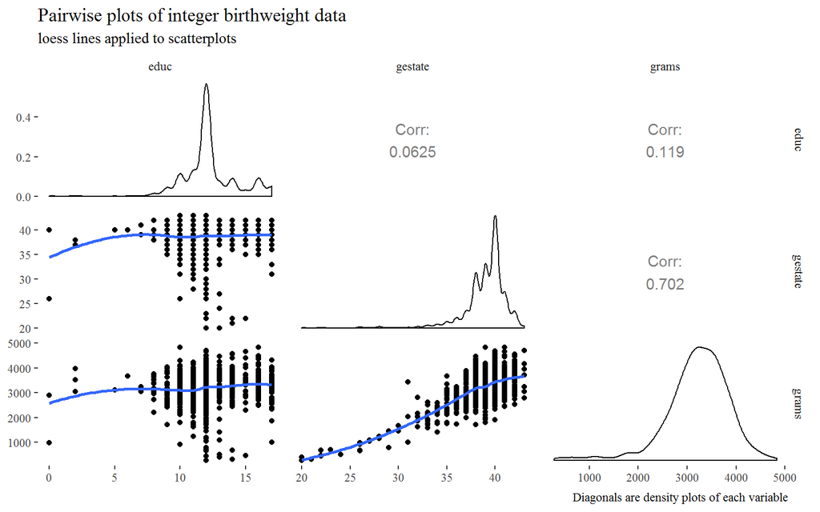

```r
# Function to return points and geom_smooth
# allow for the method to be changed
my_fn <- function(data, mapping, method="loess",...){
      p <- ggplot(data = data, mapping = mapping) +
      geom_point() +
      geom_smooth(method=method,se=F, ...)
      p
    }

ggpairs(births.df[,c(-1,-3)], lower = list(continuous = my_fn)) +
  labs(title = "Pairwise plots of integer birthweight data",
       caption = "Diagonals are density plots of each variable",
       subtitle = "loess lines applied to scatterplots") +
  theme_tufte()
```

There is quite a lot of information to digest here. Birthweight looks relatively normal with a long lefthand tail. Gestation period looks somewhat normal with a large spike around 40 weeks. Years of education recieved looks very peaky, a bimodal right hand tail. We will investigate these distributions in greater detail shortly.

Gestation period has a strong positive linear relationship with birthweight. Educational has almost no relationship with birthweight and education has almost no relationship with gestation period. These assessments from the scatterplots are supported by the correlation.

### Scatterplots (gestation period, birthweight and education)

We have some issues with overplotting of integer variables, due to the limited range of values the educ and gestate variables take. Hence, I will plot all three scatterplots (with alpha and jitter) below for closer inspection;

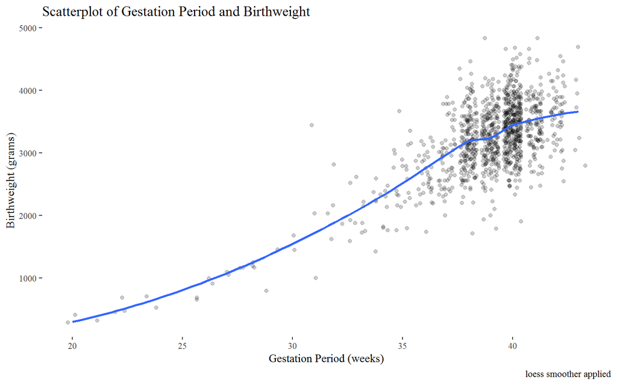

```r
ggplot(data = births.df,mapping = aes(x = gestate, y = grams)) +
  geom_jitter(alpha = 0.2) +
  geom_smooth(method = "loess",se=F) +
  theme_tufte() +
  labs(title = "Scatterplot of Gestation Period and Birthweight", x = "Gestation Period (weeks)",y = "Birthweight (grams)",caption = "loess smoother applied")
```

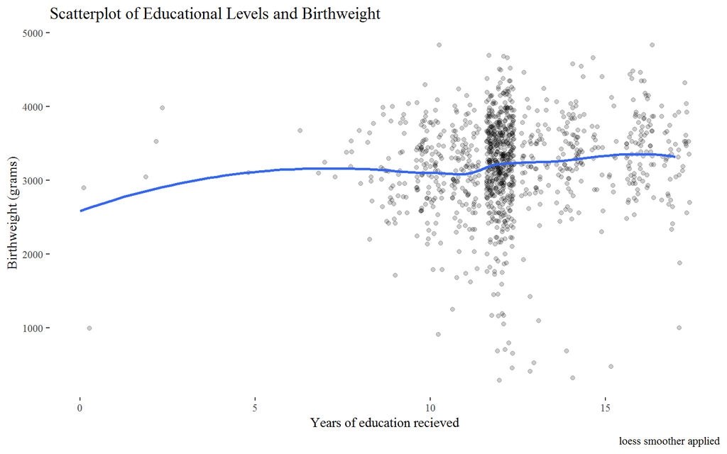

```r
ggplot(data = births.df,mapping = aes(x = educ, y = grams)) +
  geom_jitter(alpha = 0.2) +
  geom_smooth(method = "loess",se=F) +
  theme_tufte() +
  labs(title = "Scatterplot of Educational Levels and Birthweight", x = "Years of education recieved",y = "Birthweight (grams)",caption = "loess smoother applied")
```

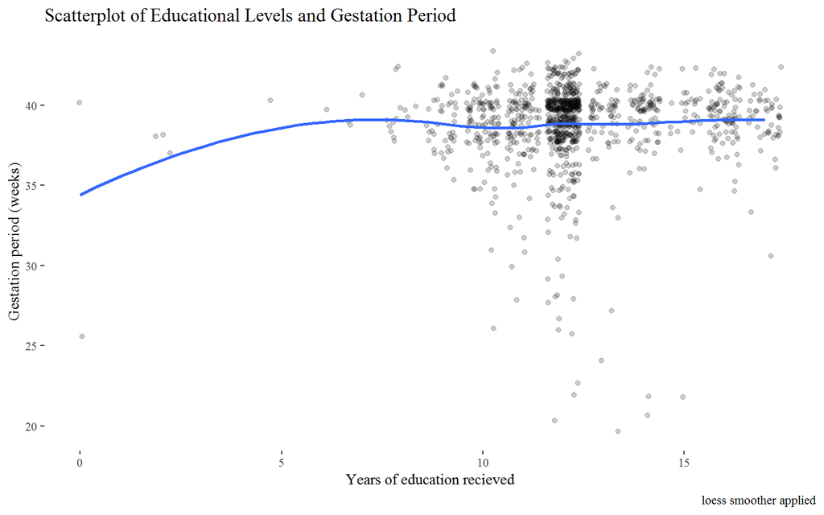

```r
ggplot(data = births.df,mapping = aes(x = educ, y = gestate)) +
  geom_jitter(alpha = 0.2) +
  geom_smooth(method = "loess",se=F) +
  theme_tufte() +
  labs(title = "Scatterplot of Educational Levels and Gestation Period", x = "Years of education recieved",y = "Gestation period (weeks)",caption = "loess smoother applied")
```

The general trends displayed here confirm what we saw in the pairwise plots. It is very clear that the relationship of birthweight and gestation period will be of great interest, from the clearly defined pattern shown. This could quite possibly be polynomial, which will help inform our modelling later on.

### Cross tabs and ch-sq test (smoking, ethnicity)

We will create some cross tabulations to investigate smoking and ethnicity. To make these easier to interpret, we will convert them to a percentage of total cases.

```r
blackSmoke_crosstab.df <- xtabs(~ black + smoke,data = births.df)
cat("frequencies")
cat("\n")
blackSmoke_crosstab.df
cat("proportions")
cat("\n")
round(blackSmoke_crosstab.df/(sum(blackSmoke_crosstab.df)),3)
```

```
## frequencies
##        smoke
## black   FALSE TRUE
##   FALSE   356   97
##   TRUE    490  172
## proportions
##        smoke
## black   FALSE  TRUE
##   FALSE 0.319 0.087
##   TRUE  0.439 0.154
```

The majority of mothers are non smokers. There appear to be more black mothers who are smokers than non-black mothers who are smokers. However, while we are at it, we may as well run a chi-sq test for statistical significance. We are testing whether the factors are independant i.e. whether they (the categorical variables in question) have any statistically significant relationship. This is done by comparing the expected counts if there was no relationship with the observed counnts. This is just about the easiest statistical test to understand taking the form;

> $$\chi ^{2*} = \sum(O_i - E_i)^2 / E_i$$

```r
summary(blackSmoke_crosstab.df)
```

```
## Call: xtabs(formula = ~black + smoke, data = births.df)
## Number of cases in table: 1115
## Number of factors: 2
## Test for independence of all factors:
##  Chisq = 3.0674, df = 1, p-value = 0.07988
```

It would appear that there is not a statistically significant difference (p > 0.05) in the number of mothers who smoke by ethnicity, although the level of statistical significance is marginal. Hence we keep the null hypothesis that the categories are indepedant. The p-value (0.08) approaches significance however, so it is perhaps something worth investigating in further detail.

We can also investigate whether ethnicity and smoking interact with regards to the response (birthweight), but creating an interaction plot:

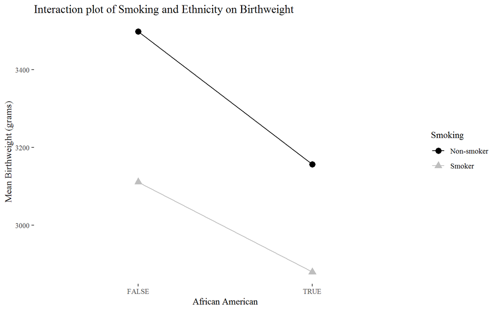

```r
#interaction.plot(births.df$black,births.df$smoke,births.df$grams,main = "Interaction plot of Smoking and Ethnicity on Birthweight",xlab = "African American",ylab = "Mean Birthweight (grams)",trace.label = "Smoking Status")

births.df %>%
  group_by(black,smoke) %>%
  summarise(birth_groups = mean(grams)) -> interact.df

interact.df %>%
  ggplot() +
  aes(x = black, y = birth_groups,color = smoke,shape = smoke) +
  geom_line(aes(group = smoke)) +
  geom_point(size = 3) +
  theme_tufte() +
  labs(title = "Interaction plot of Smoking and Ethnicity on Birthweight",
       x = "African American",
       y = "Mean Birthweight (grams)") +
  scale_color_manual(name = "Smoking",
                     values = c('black','grey'),
                     labels = c("Non-smoker","Smoker")) +
  scale_shape_discrete(name = "Smoking",
                     labels = c("Non-smoker","Smoker"))
```

As the lines are almost parallel, it appears that there is no interaction effect occuring. We can also see quite a clear deleterious effect on birthweight of both smoking and ethnicity, although we will wait until the modelling stage to clarify if this is statistically signficant.

### Boxplots (smoking and ethnicity)

However, this pairwise scatterplot leaves out the interactions involved with the **boolean variables**. How are they affected? To determine this, I have created sets of faceted boxplots with transparent outliers. This gives an idea of the continuous distributions marginalised by smoking status and ethnicity.

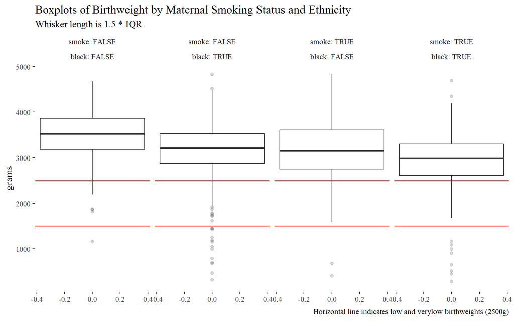

```r
smoke_levels <- c(F = 'Non smoker' ,T = 'Smoker')
black_levels <- c(F = 'Non-black',T = 'Black')

ggplot(data = births.df, mapping = aes(y = grams)) +
  geom_boxplot(outlier.alpha = 0.2) +
  facet_grid(~ smoke + black,
             labeller = labeller(smoke = label_both,black = label_both)) +
  theme_tufte() +
  labs(title = "Boxplots of Birthweight by Maternal Smoking Status and Ethnicity",subtitle = "Whisker length is 1.5 * IQR",caption = "Horizontal line indicates low and verylow birthweights (2500g)") +
  geom_hline(yintercept = c(1500,2500),color = 'red')
```

From the boxplots, we can see that the highest birthweights arose from non-African American, no-smoking mothers. This was followed by African American non-smokers, non-African American smokers and the group with the lowest birthweights were African American smokers. There appear to be interested clusters of outliers (as defined by the 1.5 * IQR rule) for both African American smokers and African American non-smokers. These will warrent further investigation.

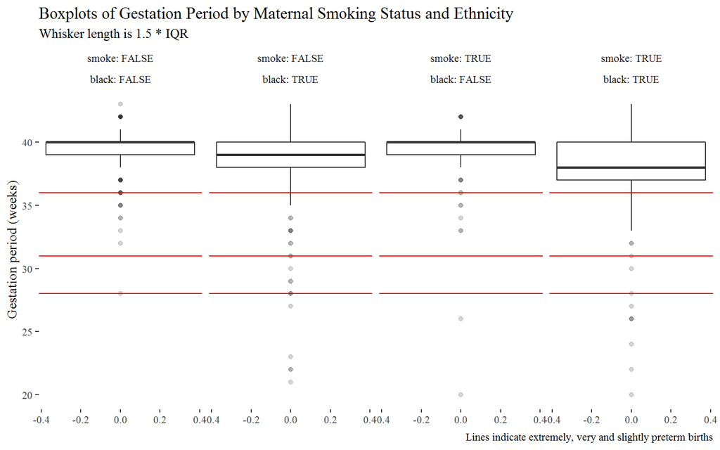

```r
smoke_levels <- c(F = 'Non smoker' ,T = 'Smoker')
black_levels <- c(F = 'Non-black',T = 'Black')

ggplot(data = births.df, mapping = aes(y = gestate)) +
  geom_boxplot(outlier.alpha = 0.2) +
  facet_grid(~ smoke + black,
             labeller = labeller(smoke = label_both,black = label_both)) +
  theme_tufte() +
  labs(title = "Boxplots of Gestation Period by Maternal Smoking Status and Ethnicity",
       subtitle = "Whisker length is 1.5 * IQR",
       caption = "Lines indicate extremely, very and slightly preterm births",
       y = "Gestation period (weeks)") +
  geom_hline(yintercept = c(28,31,36),color = 'red')
```

All distributions are left skewed. Interestingly, both non-African American smokers and non-smokers have the least premature babies. I would describe African-American babies as often premature. We observe that African-American smokers have the most premature babies, and the most extremely premature babies. We will isolate and view the extremely preterm babies, as this type of birth often results in high infant mortality.

```r
kable(births.df[births.df$gestate < 28,],caption = "Low gestation period outliers")
```

Low gestation period outliers

|  | black | educ | smoke | gestate | grams |
| --- | --- | --- | --- | --- | --- |
| 2 | TRUE | 0 | TRUE | 26 | 994 |
| 161 | TRUE | 10 | TRUE | 26 | 909 |
| 317 | TRUE | 12 | TRUE | 20 | 284 |
| 324 | TRUE | 12 | TRUE | 22 | 455 |
| 605 | TRUE | 12 | FALSE | 23 | 701 |
| 658 | TRUE | 12 | TRUE | 26 | 653 |
| 785 | FALSE | 12 | TRUE | 26 | 682 |
| 804 | TRUE | 12 | FALSE | 27 | 1051 |
| 814 | TRUE | 13 | TRUE | 24 | 521 |
| 837 | TRUE | 13 | TRUE | 27 | 1095 |
| 867 | FALSE | 13 | TRUE | 20 | 410 |
| 905 | TRUE | 14 | FALSE | 21 | 320 |
| 915 | TRUE | 14 | FALSE | 22 | 682 |
| 966 | TRUE | 15 | FALSE | 22 | 470 |

We notice a striking trend of low birth weights here. We also note that the almost all of these mothers are African American, and the majority smoke. Education levels are relatively high and does not seem to be a factor of interest here. To explain the implications of these low birthweights, I have linked to a manual from a childrens hospital on the matter;

> [UCSF Children’s Hospital Intensive Care Nursery House Staff Manual](https://www.ucsfbenioffchildrens.org/pdf/manuals/20_VLBW_ELBW.pdf)

As we have come to a fairly obvious result regarding what *should* be logical predictors of low birthweight (African American ethnicity, being a smoker, having a low gestation period), we will turn our attention to quantifying the impact of these factors later in the analysis, and also seeing if there are effects we are missing with healthy weight babies.

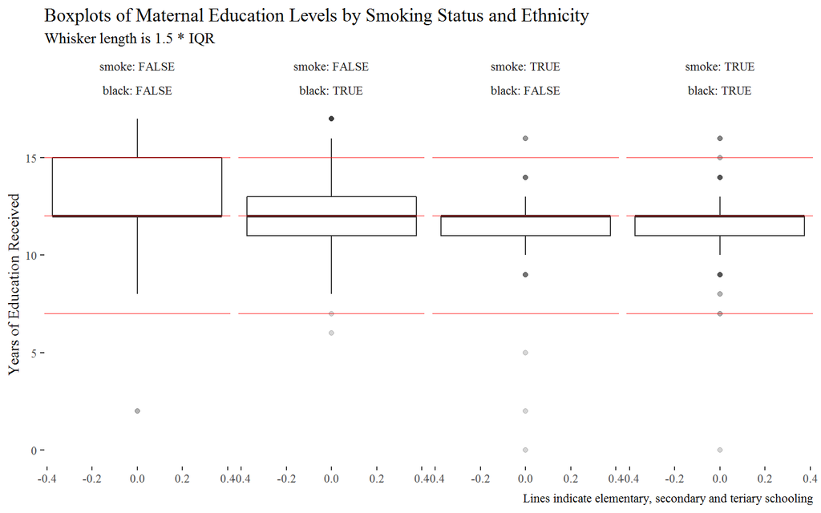

```r
smoke_levels <- c(F = 'Non smoker' ,T = 'Smoker')
black_levels <- c(F = 'Non-black',T = 'Black')

ggplot(data = births.df, mapping = aes(y = educ)) +
  geom_boxplot(outlier.alpha = 0.2) +
  facet_grid(~ smoke + black,
             labeller = labeller(smoke = label_both,black = label_both)) +
  theme_tufte() +
  labs(title = "Boxplots of Maternal Education Levels by Smoking Status and Ethnicity",
       subtitle = "Whisker length is 1.5 * IQR",
       caption = "Lines indicate elementary, secondary and teriary schooling",
       y = "Years of Education Received") +
  geom_hline(yintercept = c(7,12,15),color = 'red',alpha = 0.5)
```

Additionally, we note some outliers who have not achieved elementary (to the end of middle) school education! I believe it is worth isolating and investigating these data points.

```r
kable(births.df[births.df$educ < 7,],caption = "Low education outliers") %>%
  kable_styling(full_width = T)
```

Low education outliers

| black | educ | smoke | gestate | grams |
| --- | --- | --- | --- | --- |
| FALSE | 0 | TRUE | 40 | 2898 |
| TRUE | 0 | TRUE | 26 | 994 |
| FALSE | 2 | FALSE | 38 | 3977 |
| FALSE | 2 | TRUE | 37 | 3040 |
| FALSE | 2 | FALSE | 38 | 3523 |
| FALSE | 5 | TRUE | 40 | 3100 |
| TRUE | 6 | FALSE | 40 | 3670 |

We find that the majority of these mothers are not African American, are smokers and have healthy birthweights. It is interesting to note this group also contains an extreme outlier for birthweight (994 grams), who completed no education at all. There are only seven mothers in a sample of ~1100 that did not complete an elementary education, representing less than 1% of the sample.

### Histograms and barcharts (gestation period, birthweight, educational levels)

Following on from the density plots, we will examine the distributions of the integer variables more carefully, by plotting them individually as histograms and barcharts.

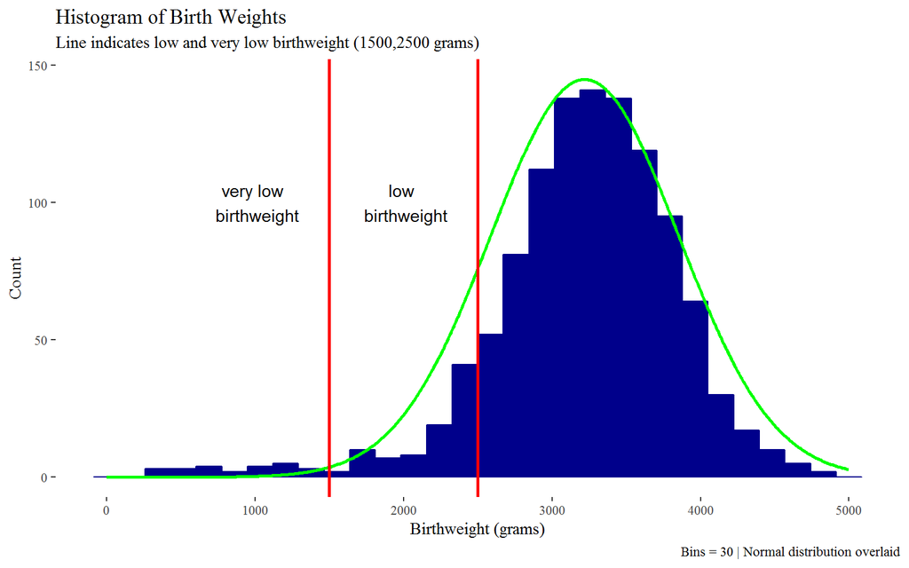

```r
x <- seq(from = 0, to = 5000, by = 10)
d <- dnorm(x, mean(births.df$grams), sd(births.df$grams))*230000
norm.df <- data.frame(x,d)

ggplot() +
  geom_histogram(data = births.df,mapping = aes(x = grams),bins = 30,colour = 'darkblue',fill = 'darkblue') +
  geom_rug(alpha = 0.2) +
  geom_line(data = norm.df,mapping = aes(x = x,y=d),lwd = 1,color = "green") +
  geom_vline(xintercept = c(1500,2500),lwd = 1,colour = "red") +
  labs(title = "Histogram of Birth Weights", x = "Birthweight (grams)",y = "Count",caption = "Bins = 30 | Normal distribution overlaid",subtitle = "Line indicates low and very low birthweight (1500,2500 grams)") +
  annotate("text",y = 100, x = 2000,label = "low \n birthweight") +
  annotate("text",y = 100, x = 1000,label = "very low \n birthweight") +
  theme_tufte()
```

From the above histogram we can see that while mostly babies are born with a healthy weight, there is also a long tail to the left of babies born underweight. The data appears to be normally distributed, but doesn’t quite map to a perfect normal distribution due to this skew.

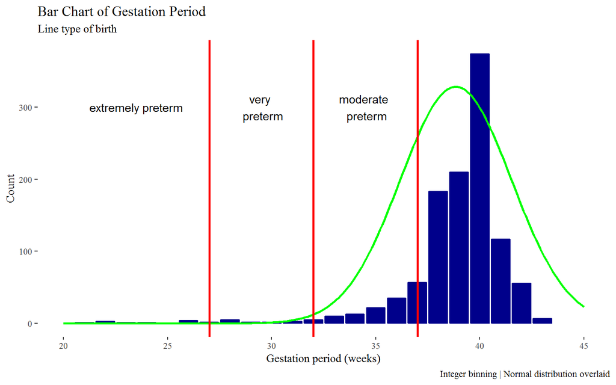

```r
x <- seq(from = 20, to = 45, by = 0.1)
d <- dnorm(x, mean(births.df$gestate), sd(births.df$gestate))*2200 #scaling up densities
norm.df <- data.frame(x,d)

ggplot() +
  geom_bar(data = births.df,mapping = aes(x = gestate),bins = 15,colour = 'darkblue',fill = 'darkblue') +
  geom_rug(alpha = 0.2) +
  geom_line(data = norm.df,mapping = aes(x = x,y=d),lwd = 1,color = "green") +
  xlim(20,45) +
  geom_vline(xintercept = 37,lwd = 1,colour = "red") +
  geom_vline(xintercept = 32,lwd = 1,colour = "red") +
  geom_vline(xintercept = 27,lwd = 1,colour = "red") +
  labs(title = "Bar Chart of Gestation Period", x = "Gestation period (weeks)",y = "Count",caption = "Integer binning | Normal distribution overlaid",subtitle = "Line type of birth") +
  annotate("text",y = 300, x = 23.5,label = "extremely preterm") +
  annotate("text",y = 300, x = 29.5,label = "very \n preterm") +
  annotate("text",y = 300, x = 34.5,label = "moderate \n preterm") +
  theme_tufte()
```

From the annotated histogram above, we can see that most babies are born around the expected time. However, there is a are quite a few babies born moderately preterm. There are very few very preterm and only a few extremely preterm babies. Generally, we can say there is a long left hand tail to this distribution - similar to birthweight. However, we additionally notice that there is a very large group of babies born at 40 weeks - the expected gestation period for humans. While I have plotted a normal curve over the data, it would not be fair to say the data is normally distributed - there are clearly constraints (for instance, no babies are born past 43 weeks, while many are born before 37 weeks) that hamper any assumptions that the distribution of gestation periods is parametric.

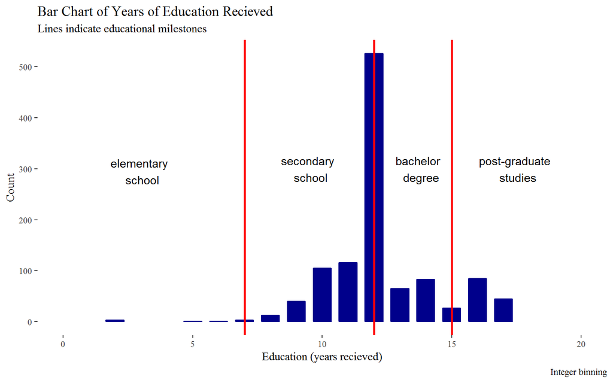

```r
x <- seq(from = 20, to = 45, by = 0.1)
d <- dnorm(x, mean(births.df$educ), sd(births.df$educ))*2200 #scaling up densities
norm.df <- data.frame(x,d)

ggplot() +
  geom_bar(data = births.df,mapping = aes(x = educ),bins = 15,colour = 'darkblue',fill = 'darkblue',width = 0.7) +
  geom_rug(alpha = 0.2) +
  geom_line(data = norm.df,mapping = aes(x = x,y=d),lwd = 1,color = "green") +
  xlim(0,20) +
  geom_vline(xintercept = 7,lwd = 1,colour = "red") +
  geom_vline(xintercept = 12,lwd = 1,colour = "red") +
  geom_vline(xintercept = 15,lwd = 1,colour = "red") +
  labs(title = "Bar Chart of Years of Education Recieved", x = "Education (years recieved)",y = "Count",caption = "Integer binning",subtitle = "Lines indicate educational milestones") +
  annotate("text",y = 295, x = 3,label = "elementary \n school") +
  annotate("text",y = 300, x = 9.5,label = "secondary \n school") +
  annotate("text",y = 300, x = 13.75,label = "bachelor \n degree") +
  annotate("text",y = 300, x = 17.5,label = "post-graduate \n studies") +
  theme_tufte()
```

This distribution shows virutally all mothers complete elementary (until the end of middle school). Most mothers make it to the end of high school (K-12). Many leave in the New Zealand equivalent of 5th/6th form (years 11 and 12); K-10 and K-11. A much smaller proportion are completing a bachelors or in post grad. What does this distribution suggest? Most mothers have completed high school, but not embarked on tertiary education. One subgroup perhaps worth investigating is mothers who have only completed 8 years of education - some of these observations might represent legal minors who may have underweight babies.

We will quickly investigate this;

```r
lessThanEight <- births.df[births.df$educ <= 8,"grams"]
NineorMore <- births.df[births.df$educ >= 8,"grams"]
t.test(births.df$grams,births.df[births.df$educ <= 8,"grams"])
```

```
##
##  Welch Two Sample t-test
##
## data:  births.df$grams and births.df[births.df$educ <= 8, "grams"]
## t = 0.51253, df = 22.978, p-value = 0.6132
## alternative hypothesis: true difference in means is not equal to 0
## 95 percent confidence interval:
##  -201.2384  333.7893
## sample estimates:
## mean of x mean of y
##  3219.536  3153.261
```

The p-value and the practical difference in group means inform us this is not a hypothesis worth investigating.

## Model selection

What do we wish to achieve with this data?

We wish to:

- Maximise prediction accuracy
- Explain as much of the variation in the data as possible
- Avoid overfitting
- Link our observational techniques to possible causal mechanisms

Simple models usually generalise to other datasets much more often than complicated models. Hence a key focus will be keeping the model simple.

### Initialisation models

We start with several models that include most or all of the possible variables and interactions. For simplicity sake, we will avoid the issue of polynomial or square root terms in our model. We will leave aside any interpretation of the model until we have selected what we consider to be the “best” model, given the data, our knowledge and expertise and our time. **small aside** when entering boolean variables into the model, they are coerced into a factor with two levels: TRUE and FALSE. The model function then sorts these lexicographically (so that F is before T) - [hat tip to SO user mnel](https://stackoverflow.com/questions/17737159/controlling-the-value-true-or-false-of-dummy-variables-in-interaction-terms-wh)

The supermodel below includes main effects, levels and *all* possible interactions, including even four-way interactions between the predictor variables. However, this may not lead to the best models selected when using the stepwise regression algorithm (“cold start problem”).

The “small” supermodel includes all main effects, levels and two way interactions, which are easier to explain and occur more oftenly in practice. We will develop both of these models further in the stepwise and subset regressions.

I have opted to just print the predictors, to emphasise that these models should not be considered viable final models. This leads to two intital models; one with 16 predictors and one with 11.

```r
superModel <- lm(data = births.df, grams ~ black*smoke*gestate*educ)
names(coefficients(superModel))
```

```
##  [1] "(Intercept)"                      "blackTRUE"
##  [3] "smokeTRUE"                        "gestate"
##  [5] "educ"                             "blackTRUE:smokeTRUE"
##  [7] "blackTRUE:gestate"                "smokeTRUE:gestate"
##  [9] "blackTRUE:educ"                   "smokeTRUE:educ"
## [11] "gestate:educ"                     "blackTRUE:smokeTRUE:gestate"
## [13] "blackTRUE:smokeTRUE:educ"         "blackTRUE:gestate:educ"
## [15] "smokeTRUE:gestate:educ"           "blackTRUE:smokeTRUE:gestate:educ"
```

```r
smallSuperModel <- lm(data = births.df, grams ~ (black + smoke + gestate + educ)^2)
names(coefficients(smallSuperModel))
```

```
##  [1] "(Intercept)"         "blackTRUE"           "smokeTRUE"
##  [4] "gestate"             "educ"                "blackTRUE:smokeTRUE"
##  [7] "blackTRUE:gestate"   "blackTRUE:educ"      "smokeTRUE:gestate"
## [10] "smokeTRUE:educ"      "gestate:educ"
```

### Stepwise regressions

Below is the results of running the automated stepwise regression routines. By default, R runs both the forwards and backwise routines, then compares the two models and selects the best one. By default, it does this on the basis of the Akakike information criterion. We can adjust the step function(set k = log(n)) to use BIC to find the best model - however as BIC is simply a varient on AIC that penalises larger models more heavily, this isn’t an especially productive exercise.

**Stepwise regression - from large model**

```r
largeStart_stepwise_model <- step(superModel,trace = F,direction = "both")
print(largeStart_stepwise_model)
```

```
##
## Call:
## lm(formula = grams ~ black + smoke + gestate + educ + black:smoke +
##     black:educ + gestate:educ, data = births.df)
##
## Coefficients:
##         (Intercept)            blackTRUE            smokeTRUE
##           -1051.332             -721.358             -333.401
##             gestate                 educ  blackTRUE:smokeTRUE
##             117.991             -136.677              246.683
##      blackTRUE:educ         gestate:educ
##              40.318                3.246
```

**Stepwise regression - from small model**

```r
smallStart_stepwise_model <- step(smallSuperModel,trace = F,direction = "both")
print(smallStart_stepwise_model)
```

```
##
## Call:
## lm(formula = grams ~ black + smoke + gestate + educ + black:smoke +
##     black:educ + gestate:educ, data = births.df)
##
## Coefficients:
##         (Intercept)            blackTRUE            smokeTRUE
##           -1051.332             -721.358             -333.401
##             gestate                 educ  blackTRUE:smokeTRUE
##             117.991             -136.677              246.683
##      blackTRUE:educ         gestate:educ
##              40.318                3.246
```

Oh dear! Both large models have been whittled down by the stepwise algorithm to the same model. While we could continue to adjust and tweak the models we feed into the stepwise regression algorithm, I believe taking alternative approachs will be more fruitful. We will save this model for comparison as a baseline and move on with our analysis.

```r
stepWise_model <- smallStart_stepwise_model
```

### Subsets regression

We will use the ‘leaps’ package to compare all possible subsets for each number of predictors, rather than iteratively adding or dropping variables. This is possible because most criteria rely on the number of parameters - hence if this is held constant, we can use one measure to compare many subsets. This package can also perform forward and backwards stepwise regression, but here we are using it to perform an exhaustive search of all possible subsets of predictors (an ‘exhaustive’ search). We are starting from the large “supermodel” we defined before the stepwise regression stage.

Apologies for the small text size (just fitting the text on the plot required editing the package functions!).

```r
#REF: https://stackoverflow.com/questions/21708764/cannot-change-text-size-in-regsubsets-plot
plot.regsubsets2 <-
function (x, labels = obj$xnames, main = NULL, scale = c("bic",
    "Cp", "adjr2", "r2"), col = gray(seq(0, 0.9, length = 10)),
    ...)
{
    obj <- x
    lsum <- summary(obj)
    par(mar = c(7, 5, 6, 3) + 0.1)
    nmodels <- length(lsum$rsq)
    np <- obj$np
    propscale <- FALSE
    sscale <- pmatch(scale[1], c("bic", "Cp", "adjr2", "r2"),
        nomatch = 0)
    if (sscale == 0)
        stop(paste("Unrecognised scale=", scale))
    if (propscale)
        stop(paste("Proportional scaling only for probabilities"))
    yscale <- switch(sscale, lsum$bic, lsum$cp, lsum$adjr2, lsum$rsq)
    up <- switch(sscale, -1, -1, 1, 1)
    index <- order(yscale * up)
    colorscale <- switch(sscale, yscale, yscale, -log(pmax(yscale,
        1e-04)), -log(pmax(yscale, 1e-04)))
    image(z = t(ifelse(lsum$which[index, ], colorscale[index],
        NA + max(colorscale) * 1.5)), xaxt = "n", yaxt = "n",
        x = (1:np), y = 1:nmodels, xlab = "", ylab = scale[1],
        col = col)
    laspar <- par("las")
    on.exit(par(las = laspar))
    par(las = 2)
    axis(1, at = 1:np, labels = labels, ...) # I modified this line
    axis(2, at = 1:nmodels, labels = signif(yscale[index], 2))
    if (!is.null(main))
        title(main = main)
    box()
    invisible(NULL)
}

#Code reference: https://rstudio-pubs-static.s3.amazonaws.com/2897_9220b21cfc0c43a396ff9abf122bb351.html
#No listed author
subsetsModel <- regsubsets(data = births.df,
                           grams ~ black*smoke*gestate*educ,
                           #nbest = 3,
                           nbest = 1,
                           nvmax = NULL,
                           force.in = NULL,
                           force.out = NULL,
                           method = "exhaustive")
```

Please select the tabs below to see the interpretations for each criterion.

#### R-sq

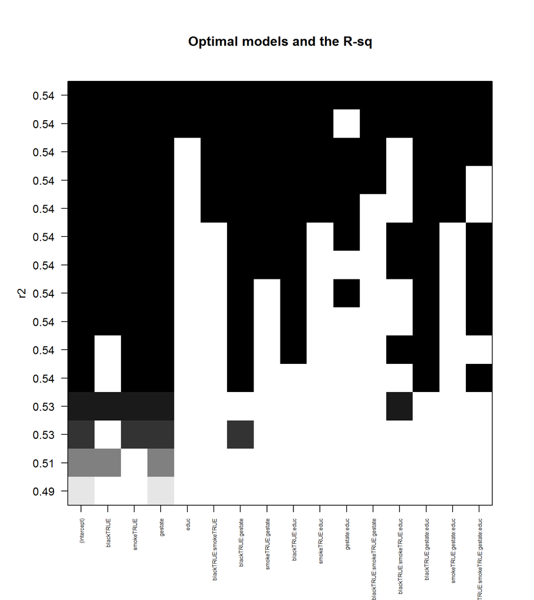

```r
r2Plot <- plot.regsubsets2(subsetsModel,scale = "r2",
     main = "Optimal models and the R-sq",
     #labels = c("(Intercept)","Black","Smoke","Gestate","Educ",""),
     cex.axis = 0.5)
```

The first plot shows the ideal model (as measured by highest $R^2$) for each number of predictor variables, ordered by the model criterion we have plotted. We immediately see that large improvements in $R^2$ are not obtained from higher numbers of predictor variables. I have plotted $R^2$ as opposed to $adjusted \, R^2$ as this is a nice illustration that $R^2$ always increases with $p$. It also nicely demonstrates that gestate (and the intercept) account for most of variance in birthweight. The simple model with only gestate in it has $R^2$ = 0.49 - we can explain most of the variation that is able to be explained using our sets of main effects and interactions (as shown by the maximum $R^2$ of 0.54) with just this simple model.

#### BIC

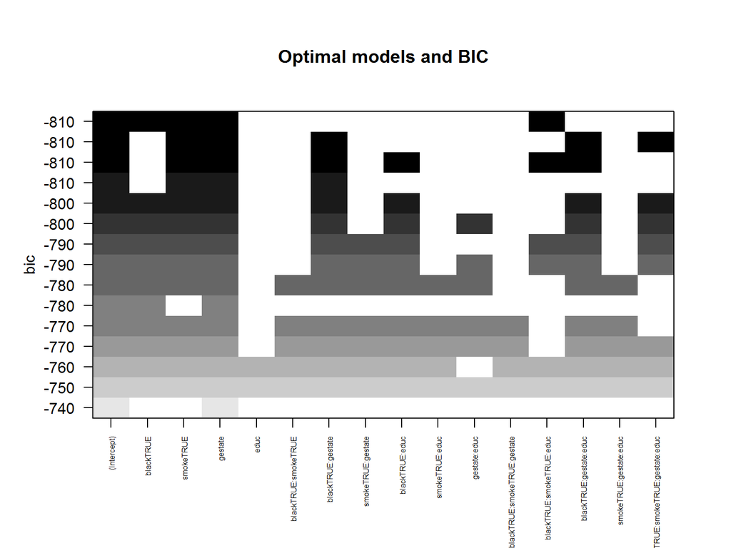

```r
bicPlot <- plot.regsubsets2(subsetsModel,
     scale = "bic",
     main = "Optimal models and BIC",
     cex.axis = 0.5)
```

For the formula for the Bayesian Information Criterion is;

> $$BIC = ln(n)k - 2 \, ln \, (\hat{L})$$

Where $k$ is the number of parameters, $n$ is the number of observations and $\hat{L}$ is the maximised log-likelihood.

This is refered to as a penalised-likilihood test. BIC, given many n (observations), is unlikely to choose a too large model, but may be more likely than AIC to choose a smaller model.

#### Mallow’s Cp

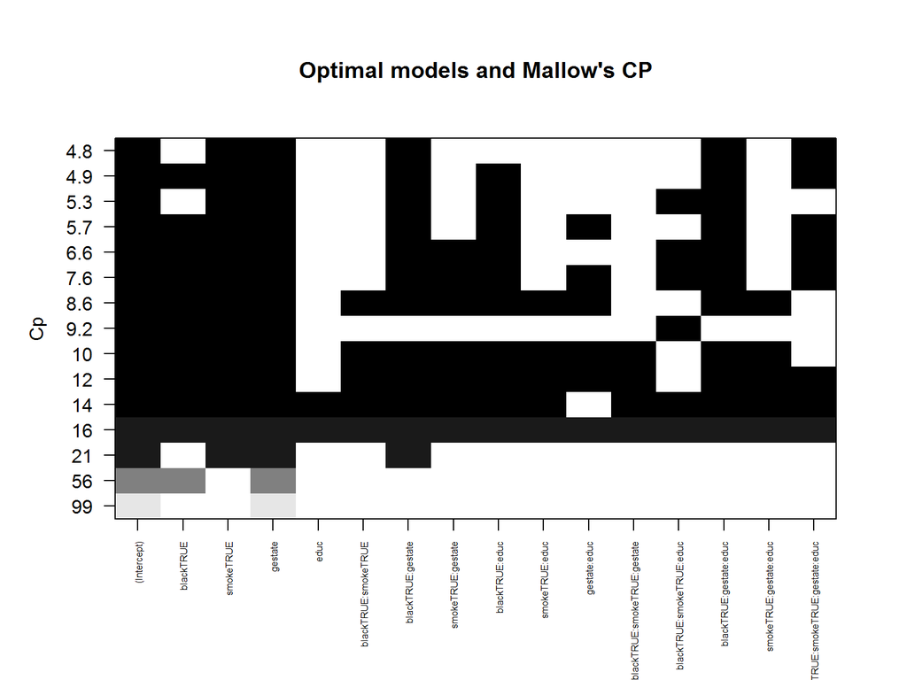

```r
cpPlot <- plot.regsubsets2(subsetsModel,
     scale = "Cp",
     main = "Optimal models and Mallow's CP",
     cex.axis = 0.5)
```

The broad ideas here are that we look for;

- p != Cp (don’t use Cp to evaluate full model)
- Cp near or below p (no bias)
- Avoid large values of Cp (suggests important predictors are missing)
- Then choose the simplest or most appropriate model

We find here very high Cp values for our simplistic models, suggesting they may be biased (underspecified), by not including enough variables or interactions. The model with a Cp value of 9.2 might be a good compromise between complexity and bias. Beyond that, at smaller Cp values, we are left with a variety of models which generally exclude educ but include different combinations of other interactions. We will address these when we review the criterion matrix later.

#### Adj. R-sq

$R^2$ is calculated as follows;

$$R^{2}_a = 1 -\frac{RSS / (n-p)}{TSS / (n - 1)}$$

Hence we have a figure that is identical to $R^2$ but is penalised by degrees of freedom. This accounts for the complexity of the model (number of parameters). This reflects a symptom of the data collection and study design discussed earlier: significant predictors that could explain variance in the data (alcohol consumptions, mothers weight etc) are not included in the dataset. It also informs us, given the data we have, models beyond more than four parameters (especially very complex models, as seen near the top of the chart) are probably not worth the loss of degrees of freedom and risk of overfitting.

```r
adjr2Plot <- plot.regsubsets2(subsetsModel,
     scale = "adjr2",
     main = "Optimal models and Adj. R-sq",
     cex.axis = 0.5)
```

[figure not shown]

We find that $R^2$ is virtually identical for models with four or parameters - hence varying combinations of extra and increasing complex interactions are unlikely to explain a greater proportion of variation in the data.

We have reviewed the criterion plots for the subset regression.

Now that we know the optimal model for each $p$, we must choose $p$. This will essentially be a manual consideration of the tradeoff in complexity and fit of the model. This involves a comparison of the relevant criterion;

```r
summarySubsetsModel <- summary(subsetsModel)
subsetCrit.df <- as.data.frame(cbind(summarySubsetsModel$rsq,summarySubsetsModel$adjr2,summarySubsetsModel$cp,summarySubsetsModel$bic),row.names = F)
subsetCrit.df <- cbind(seq(1:15),subsetCrit.df)
#subsetCrit.df <- cbind(seq(1:43),subsetCrit.df)
colnames(subsetCrit.df) <- c("predictors","rsq","adjr2","cp","bic")
row.names(subsetCrit.df) <- NULL
kable(round(subsetCrit.df,3),caption = "Criterion for Best Subset Models") %>%
  kable_styling(full_width = T)
```

Criterion for Best Subset Models

| predictors | rsq | adjr2 | cp | bic |
| --- | --- | --- | --- | --- |
| 1 | 0.493 | 0.492 | 98.508 | -743.158 |
| 2 | 0.512 | 0.511 | 55.956 | -777.987 |
| 3 | 0.527 | 0.526 | 21.445 | -806.475 |
| 4 | 0.533 | 0.531 | 9.154 | -813.669 |
| 5 | 0.536 | 0.533 | 4.806 | -813.024 |
| 6 | 0.536 | 0.534 | 5.346 | -807.477 |
| 7 | 0.537 | 0.534 | 4.879 | -802.950 |
| 8 | 0.538 | 0.534 | 5.725 | -797.100 |
| 9 | 0.538 | 0.534 | 6.635 | -791.186 |
| 10 | 0.539 | 0.534 | 7.587 | -785.230 |
| 11 | 0.539 | 0.534 | 8.552 | -779.262 |
| 12 | 0.539 | 0.534 | 10.059 | -772.746 |
| 13 | 0.539 | 0.534 | 12.030 | -765.759 |
| 14 | 0.539 | 0.533 | 14.002 | -758.771 |
| 15 | 0.539 | 0.533 | 16.000 | -751.756 |

```r
coef(subsetsModel,4)
```

```
##              (Intercept)                blackTRUE                smokeTRUE
##              -2707.57600               -226.69651               -327.45444
##                  gestate blackTRUE:smokeTRUE:educ
##                157.18976                 19.94647
```

Unfortunately, this model includes a three way interaction term without including two way interaction terms. This is generally considered a fairly illogical selection - especially context. Why would ethnicity interact with the level of education only dependant on whether the mother is a smoker or not? If a model cannot pass a sanity test like this, and is not a clear standout then it should probably be abandoned in favour of an alternate approach.

At this point we could go back to our subsets algorithm and allow the two (or three) best models for each number of predictors to be included in the object from which we will extract coefficients and model terms. However, this is started to go down the road of data mining and is a redundant exercise for models with low numbers of parameters (which we intuitively think are likely).

### Hierarchical (simple) model

We begin by investigating the possibility of an observed polynomial relationship of gestate and grams.

```r
nonpoly.lm <- lm(data = births.df,grams ~ gestate)
poly.lm  <- lm(data = births.df,grams ~ poly(gestate,2))
sqrt.lm  <- lm(data = births.df,grams ~ sqrt(gestate))
stargazer(nonpoly.lm,poly.lm,sqrt.lm,type = 'html',title = "Investigating Polynomial Terms",column.labels=c("Ordinary","Polynomial","Square root"))
```

**Investigating Polynomial Terms**

|  | *Dependent variable:* |  |  |
| --- | --- | --- | --- |
|  | grams |  |  |
|  | Ordinary | Polynomial | Square root |
|  | (1) | (2) | (3) |
| gestate | 166.446*** |  |  |
|  | (5.060) |  |  |
| poly(gestate, 2)1 |  | 14,845.390*** |  |
|  |  | (451.050) |  |
| poly(gestate, 2)2 |  | -693.269 |  |
|  |  | (451.050) |  |
| sqrt(gestate) |  |  | 1,939.319*** |
|  |  |  | (58.913) |
| Constant | -3,245.446*** | 3,219.536*** | -8,858.645*** |
|  | (197.011) | (13.508) | (367.161) |
| Observations | 1,115 | 1,115 | 1,115 |
| R<sup>2</sup> | 0.493 | 0.494 | 0.493 |
| Adjusted R<sup>2</sup> | 0.492 | 0.493 | 0.493 |
| Residual Std. Error | 451.326 (df = 1113) | 451.050 (df = 1112) | 451.153 (df = 1113) |
| F Statistic | 1,081.938*** (df = 1; 1113) | 542.813*** (df = 2; 1112) | 1,083.621*** (df = 1; 1113) |
| *Note:* | p<0.1; p<0.05; p<0.01 |  |  |

The model below includes the variables and interactions I think will be related to birthweight. This would be smoking, ethnicity and gestation period. I have included the stepwise regression model as a comparison.

```r
chosen_Model <- lm(data = births.df, grams ~ black + smoke + gestate)
stargazer(chosen_Model,stepWise_model,type = 'html',title = "Viable Regression Models",column.labels=c("Simple","Step Wise"),covariate.labels=c("African American","Smoking",
"Gestation period (weeks)","Years of Education","AfricanAmerican:Smoking","AfricanAmerican:Education","Gestation Period:Education","Constant"))
```

**Viable Regression Models**

|  | *Dependent variable:* |  |
| --- | --- | --- |
|  | grams |  |
|  | Simple | Step Wise |
|  | (1) | (2) |
| African American | -174.402*** | -721.358*** |
|  | (27.027) | (168.870) |
| Smoking | -185.015*** | -333.401*** |
|  | (30.883) | (51.616) |
| Gestation period (weeks) | 156.570*** | 117.991*** |
|  | (5.016) | (26.612) |
| Years of Education |  | -136.677 |
|  |  | (85.093) |
| AfricanAmerican:Smoking |  | 246.683*** |
|  |  | (64.791) |
| AfricanAmerican:Education |  | 40.318*** |
|  |  | (13.244) |
| Gestation Period:Education |  | 3.246 |
|  |  | (2.156) |
| Constant | -2,713.653*** | -1,051.332 |
|  | (199.723) | (1,050.520) |
| Observations | 1,115 | 1,115 |
| R<sup>2</sup> | 0.527 | 0.537 |
| Adjusted R<sup>2</sup> | 0.526 | 0.534 |
| Residual Std. Error | 436.342 (df = 1111) | 432.607 (df = 1107) |
| F Statistic | 412.424*** (df = 3; 1111) | 183.143*** (df = 7; 1107) |
| *Note:* | p<0.1; p<0.05; p<0.01 |  |

We find that R-sq and adjusted R for the simple model are almost the same as the complex model selected by the stepwise regression! Is the more complex step-wise model superior to the simple model? Since the simple model is nested with the complex model, we can run an ANOVA (analysis of variance) to determine if there is a statistically significant difference how much of the variation in the response the model explains. This takes the form;

> $$F = \frac{(RSS_B - RSS_A) / (p - q)}{RSS_A /(n-p-1)}$$

Where p is the number of parameters in the small model and q is the number of parameters in the large model. Hence, we are testing whether the reduction in residual sums of squares (error) is significant, given the loss of degrees of freedom. The F values will take the form;

> $$F_{p-q,n-p-1}$$

```r
anova(chosen_Model,stepWise_model)
```

```
## Analysis of Variance Table
##
## Model 1: grams ~ black + smoke + gestate
## Model 2: grams ~ black + smoke + gestate + educ + black:smoke + black:educ +
##     gestate:educ
##   Res.Df       RSS Df Sum of Sq      F    Pr(>F)
## 1   1111 211528356
## 2   1107 207173699  4   4354658 5.8171 0.0001239 ***
## ---
## Signif. codes:  0 '***' 0.001 '**' 0.01 '*' 0.05 '.' 0.1 ' ' 1
```

As p < 0.05, there is a statistically significant difference in the amount of variation the two models explain. But is this the best variant of the model? According to the stepwise algorithm it is, but if we run tests on single term deletions, we can determine which interactions (first) and main effects (if they are not involved in any interactions), we can drop without losing any significant explanatory power.

```r
drop1(stepWise_model,test = "F")
```

```
## Single term deletions
##
## Model:
## grams ~ black + smoke + gestate + educ + black:smoke + black:educ +
##     gestate:educ
##              Df Sum of Sq       RSS   AIC F value    Pr(>F)
## <none>                    207173699 13544
## black:smoke   1   2712894 209886593 13556 14.4959 0.0001482 ***
## black:educ    1   1734270 208907969 13551  9.2668 0.0023885 **
## gestate:educ  1    424117 207597816 13544  2.2662 0.1325087
## ---
## Signif. codes:  0 '***' 0.001 '**' 0.01 '*' 0.05 '.' 0.1 ' ' 1
```

It looks like we can afford to drop the interaction of gestatation period and educational level. The p-value given are what we would find if we ran a series of ANOVAs on the model, specifying each term last.

```r
stepWise_dropOne.lm <- lm(data = births.df, grams ~ smoke + black + educ + gestate + black:smoke + black:educ)
drop1(stepWise_dropOne.lm,test = "F")
```

```
## Single term deletions
##
## Model:
## grams ~ smoke + black + educ + gestate + black:smoke + black:educ
##             Df Sum of Sq       RSS   AIC F value    Pr(>F)
## <none>                   207597816 13544
## gestate      1 186769215 394367031 14257 996.833 < 2.2e-16 ***
## smoke:black  1   2817103 210414919 13557  15.036 0.0001117 ***
## black:educ   1   1435008 209032824 13550   7.659 0.0057431 **
## ---
## Signif. codes:  0 '***' 0.001 '**' 0.01 '*' 0.05 '.' 0.1 ' ' 1
```

However, rerunning this process, we find we are unable to delete any more terms from the model, as this would result in a statistically significant difference in the explanatory power of the model. Hence we will use this model for our final interpretation and look at the diagnostic plots to check we have not violated any assumptions.

## Assumptions and transformations

### Residual plots

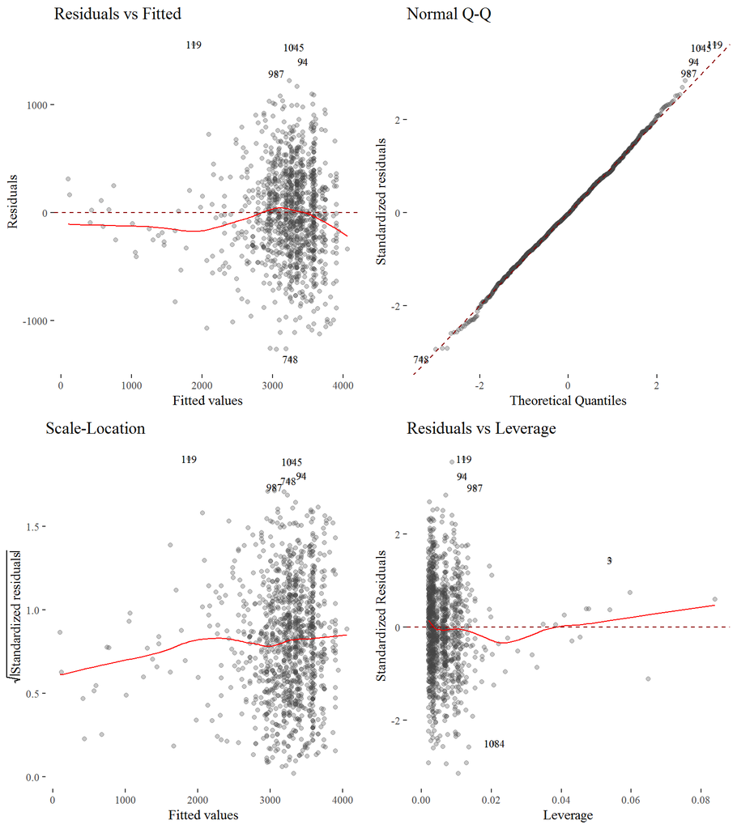

```r
autoplot(stepWise_dropOne.lm,
         alpha = 0.3,
         smooth.colour = 'red',
         ad.colour = 'darkred',
         label.size = 3,
         ad.size = 0.4,
         label.n = 5,
         label.repel = T,
         label.family = 'serif')+
  theme_tufte()
```

In a nutshell: all is well.

- The **Normal Q-Q** plot: the residuals fit the ECDF very well. There is some deviation at high residual values, likely due to the model not fitting high birthweights particulary well. Hence the assumption of the normality of the residuals is not violated.
- The **Residuals vs Fitted** plot: the residuals are spread out in a fairly random pattern, there doesn’t appear to be any trend left in the residuals that we could model.
- The **Scale-Location** plot: the residuals have a good degree of scatter across the range of the data. Again, due to the sparsity of low birthweight babies, residuals at low fitted values appear to have less variance. Hence the assumption of constant variance in the residuals is not violated.
- The **Residuals vs Leverage** plot: the residuals generally have very low leverage, although they are quite large. No residuals are within the 0.5 cooks boundary (which is so far away it is not plotted), hence we can be confident that our regression has not been affected.

In summary, we do not need to worry about excluding influential points or transforming the predictors or response variables.

We could also produce a histogram of the residuals;

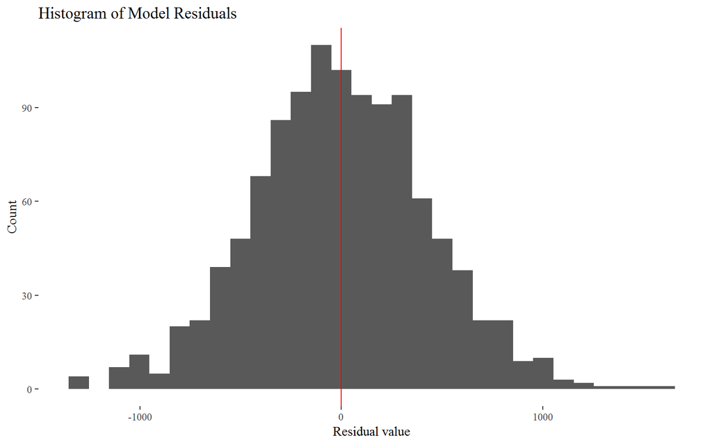

```r
ggplot(data = data.frame(stepWise_dropOne.lm$residuals), mapping = aes(x = stepWise_dropOne.lm$residuals)) +
  geom_histogram(bins = 30) +
  labs(title = "Histogram of Model Residuals",
       x = "Residual value",
       y = "Count") +
  theme_tufte() +
  geom_vline(xintercept = 0,color = 'red')
```

Which clearly emphasises how normal the residuals are normally distributed.

### Quantitiative tests and indicators

To confirm that influential points are not an issue, I calculate the maximum cooks distance;

```r
print("Max cooks distance")
```

```
## [1] "Max cooks distance"
```

```r
max(cooks.distance(stepWise_dropOne.lm))
```

```
## [1] 0.02304157
```

To obtain more quantitative assurance of normality, we will run a shapiro test to check for normality of the residuals;

```r
shapiro.test(stepWise_dropOne.lm$residuals)
```

```
##
##  Shapiro-Wilk normality test
##
## data:  stepWise_dropOne.lm$residuals
## W = 0.99843, p-value = 0.4094
```

As the p-value is greater than 0.05 we do not reject the null hypothesis that the residuals are drawn from a normal distribution.

To obtain more quantitative assurance of homoscedasticity , we will run a Breush Pagan test to check for homogeneity of variance in the residuals;

```r
lmtest::bptest(stepWise_dropOne.lm)
```

```
##
##  studentized Breusch-Pagan test
##
## data:  stepWise_dropOne.lm
## BP = 10.998, df = 6, p-value = 0.08845
```

```r
ncvTest(stepWise_dropOne.lm)
```

```
## Non-constant Variance Score Test
## Variance formula: ~ fitted.values
## Chisquare = 1.438162    Df = 1     p = 0.2304369
```

> [Link to discussion regarding BP Tests](https://stats.stackexchange.com/questions/193061/what-is-the-difference-between-these-two-breusch-pagan-tests)

To be thorough, we will create a boxcox plot and inspect the points labelled on the diagnostic plots. This is a valid procedure, as all of our response observations are greater than zero.

### Box cox transformation

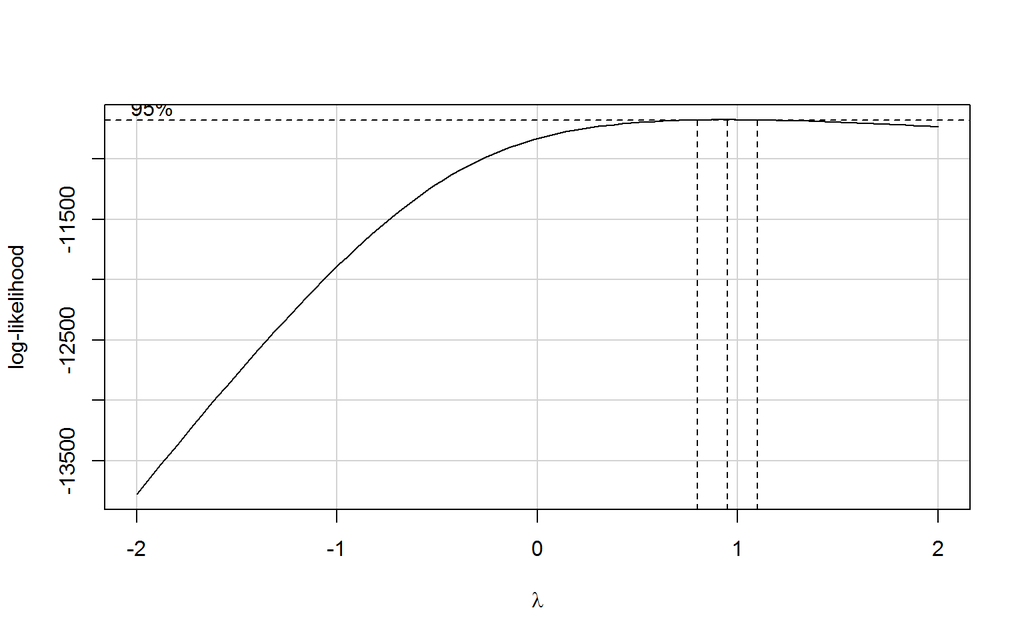

```r
boxCox(stepWise_dropOne.lm,main = "BoxCox plot")
```

The formula for the boxcox transformation is;
$$\begin{equation*}
f(y) = \begin{cases}
\frac{y^{\lambda}-1}{\lambda} \, \text{for } \lambda \neq 0 \\
log_e (y) \, \text{for } \lambda = 0
\end{cases}
\end{equation*}$$

The suggested value of $\lambda$ is 1, as indicated by the confidence bounds on the plot. We wish to maximise the log-likelihood (this is how MLE works). Plugging this into the equation yields the transformation $\frac{y^{1}-1}{1}$ i.e. 1. Hence, no transformation is neccesary.

### Outliers?

I have specified outliers to be shown on the diagnostic plots. We will investigate these individually, refering to them by row number;

```r
kable(births.df[c(119,1045,94,1084,987,748,3),],caption = "Outliers on Residual Plots")
```

Outliers on Residual Plots

|  | black | educ | smoke | gestate | grams |
| --- | --- | --- | --- | --- | --- |
| 119 | TRUE | 10 | FALSE | 31 | 3438 |
| 1045 | TRUE | 16 | FALSE | 39 | 4830 |
| 94 | FALSE | 10 | TRUE | 41 | 4830 |
| 1084 | TRUE | 17 | FALSE | 31 | 997 |
| 987 | TRUE | 16 | TRUE | 38 | 4347 |
| 748 | FALSE | 12 | TRUE | 40 | 1900 |
| 3 | FALSE | 2 | FALSE | 38 | 3977 |

We can see that several of the observations represent particulary heavy babies (1045,94) that are poorly modelled (because they have mothers that are African American or Smoke). Suprisingly, only one of the outliers (1084) on the diagnostic plots is an underweight baby - indicating that we have modelled low birthweight babies reasonably well. One observation (748) reflects a baby born with the expected normal gestation period, but has a suprisingly low birthweight (resulting in a very negative residual). The other two observations are cases where the babies were born with a reasonably healthy weight despite being born very early (119) or being born to an African American smoker and having an above average weight (987). The last observation (3) is an outlier due to having a very low value of education while still having a healthy birthweight.

A key point is that none of the outliers marked by the diagnostic plots are so unusual that they could be due to error, or reflect subgroups worth modelling seperately. Given our set of predictors (especially gestation period), a key outcome is very low birthweights, hence it would be unwise to filter out very low birthweight babies.

In conclusion, our model might not be perfect (especially regarding the issue of heteroscedasticity), but it meets enough assumptions that I feel transformations are not neccesary process to embark on. I also feel reasonably confident we can *use* this model.

## Results

The final model is a reasonably parsimonious one, having the initial four variables as predictors and two interaction terms.

```r
stargazer(stepWise_dropOne.lm,
          title = "Final Model",
          type = 'html',
          covariate.labels=c("Smoking","African American","Years of Education","Gestation period (weeks)","AfricanAmerican:Smoking","AfricanAmerican:Education","Constant"))
```

**Final Model**

|  | *Dependent variable:* |
| --- | --- |
|  | grams |
| Smoking | -334.659*** |
|  | (51.639) |
| African American | -666.252*** |
|  | (164.949) |
| Years of Education | -9.279 |
|  | (8.885) |
| Gestation period (weeks) | 157.345*** |
|  | (4.984) |
| AfricanAmerican:Smoking | 251.117*** |
|  | (64.761) |
| AfricanAmerican:Education | 35.660*** |
|  | (12.885) |
| Constant | -2,594.888*** |
|  | (228.706) |
| Observations | 1,115 |
| R<sup>2</sup> | 0.536 |
| Adjusted R<sup>2</sup> | 0.533 |
| Residual Std. Error | 432.854 (df = 1108) |
| F Statistic | 213.045*** (df = 6; 1108) |
| *Note:* | p<0.1; p<0.05; p<0.01 |

While interpreting the coefficients, bear in mind that the all of the actual effects are equally likely to lie anywhere within the confidence intervals (with the usual caveat that the true population parameters may also lie outside these intervals). Just because one coefficient may lie near the bottom of it’s interval does not mean the same applies to the other coefficients. Hence, given the width of confidence intervals we have quite a range of true population parameters that could reflect the “true” model (given our data and predictors). We will address this further down. This is a similar idea (although not quite the same as it applies to the shape of GAMs) as illustrated here;

> [Illustration of uncertainty in GAMs](https://twitter.com/noamross/status/1036977431356178434)

We find that;

- The **intercept** of the model was found to be statistically significant and highly negative. Taken at face value (ignoring context) mothers who do not smoke, are not African American, have zero years of education and have zero weeks of gestation will have babies that weight -2595g. What does this mean? We will address this in detail below.
- **Smoking** has a significant negative effect on birthweights; mothers who smoke and are not African American will have babies 334g lighter than non-smoking non-African American mothers on average.
- **African American** ethnicity has a signficant negative effect on birthweights; mothers who are African American and do not smoke will have babies -666g lighter on average.
- Due to the **interaction with ethnicity and smoking**, mothers who smoke and are also African American will not have the full deleterious main effects of smoking and ethnicity on birthweight; they will have babies (-666g + -335g + 251g = ) -750g lighter on average.
- **Education**, while in the model, was not found to have a statistically significant main effect for non-African Americans (at the $\alpha$ = 0.05 level of confidence).
- However, the **interaction of African American ethnicity and education** was found to be statistically significant and positive. Given that a mother is African American, we expect each additional year of education to add (-9.3g + 35.6g = ) 26.3g to the birthweight of the baby.
- **Gestation period** has a significant positive effect on birthweights; for each additional week a baby stays in the womb, we expect the birthweight of that baby to increase by 157g.

Given that the only significant, positive and non-categorical influence on birthweights is gestation period, it suggests a mother will need to have a baby who experiences at least 16.5 weeks in the womb to have a positive birthweight. Of course, we know that from the point of conception a baby’s weight is positive - hence interpreting the intercept in a literal sense is not logical.

The best way we can interpret this intercept is as a “lower bound” for gestational period. We know that babies born weighing less than 1500g are extremely underweight. Hence, holding all other factors constant (assuming the base level of the contrasts and zero educational level) we would anticipate that the minimal gestation period require to avoid having an extremely underweight baby is $\frac{(2595 + 1500)}{157} = 26 \, weeks)$. This aligns with what we observed from birthweights in the dataset.

The $R^2$ value is 0.54. This suggests the model explains 54% of the variation of birthweight. The F statistic is 213, which leads to a p-value of $\approx 0$ - hence the model is highly significant (against the null hypothesis that the variation in birthweights could be equally well explained by a mean model).

We can also produce confidence intervals for our model;

```r
kable(confint(stepWise_dropOne.lm),caption = "95% Confidence Intervals for Regression Coefficients")
```

95% Confidence Intervals for Regression Coefficients

|  | 2.5 % | 97.5 % |
| --- | --- | --- |
| (Intercept) | -3043.63389 | -2146.141816 |
| smokeTRUE | -435.98018 | -233.337545 |
| blackTRUE | -989.90062 | -342.604375 |
| educ | -26.71225 | 8.154114 |
| gestate | 147.56634 | 167.122945 |
| smokeTRUE:blackTRUE | 124.04808 | 378.185553 |
| blackTRUE:educ | 10.37749 | 60.941847 |

At the 95% level of confidence, we are confidence that 95% of the intervals we produce using this method, given the assumptions are satisfied and given we generate an infinite amount of intervals, will contain the true population parameters.

The intervals shown gives us a practical understanding of the significance of education (alone) in our model: it isn’t (the population parameter could plausibly be zero). We can see some of the confidence intervals are quite wide, which has implications for evaluating the importance of certain factors involved in birthweights. For example, we might expect birthweights of African American babies (given that the mothers do not smoke and have 0 years of education) by as much as nearly approx. 1kg (!) or as little as approx. -350g (an effect small enough to be potentially mitigated by the beneficial interaction of ethnicity and education).

## Predictions and fitted values

To make sense of the data, we will now look at some predictions and the fitted values. First, we bind the fitted values to the original dataframe, and generate some informative plots.

```r
births_fit.df <- cbind(stepWise_dropOne.lm$fitted.values,births.df)
colnames(births_fit.df)[1] <- c("grams_fit")
```

We know from the modelling process that the explanation of the variation in birthweights is dominated by the effect of gestation period, which is an intuitive result. We can demonstrate this by plotting the fitted values against gestation period;

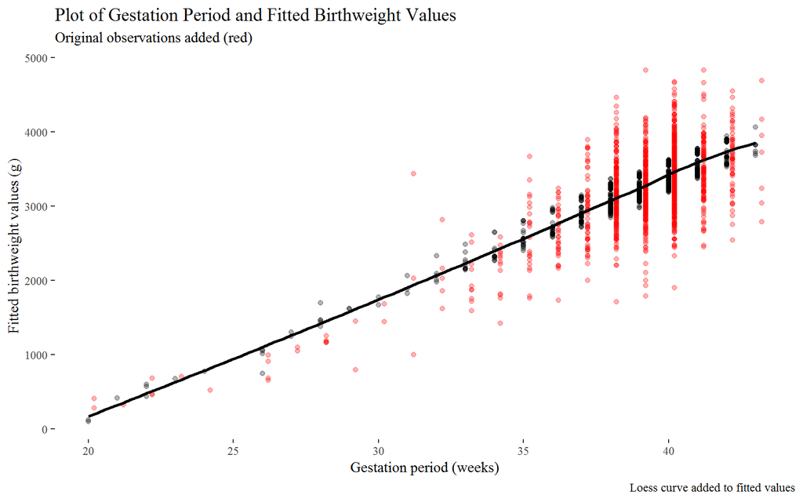

```r
ggplot(data = births_fit.df,mapping = aes(y = grams_fit, x = gestate)) +
  geom_point(alpha = 0.3) +
  geom_point(mapping = aes(x = gestate, y = grams,group = gestate),
              alpha = 0.3,
              color = 'red',
              position = position_nudge(x = 0.2)) +
  geom_smooth(se = F, method = 'loess',colour = 'black',alpha = 0.5) +
  labs(title = "Plot of Gestation Period and Fitted Birthweight Values",
       caption = "Loess curve added to fitted values",
       subtitle = "Original observations added (red)",
       x = "Gestation period (weeks)",
       y = "Fitted birthweight values (g)") +
  theme_tufte()
```

This plot also demonstrates a critical issue with the data, that the variation in observed birthweights at each week of gestation is much greater than what are model would predict given a matrix of predictor values. Again, this is because the model is underspecified - there are likely many other sources of variation involved in birthweights.

How can we show what the modell suggests without the use of a predictor table? By creating some new data.

I have expanded upon faraways use of the ‘expand.grid’ in base R to produce every possible integer combination of the predictor variables. These cover every combination of;

- Mothers who are smokers and non-smokers
- African American and non-African American mothers
- Mothers who have gestation periods from 15 to 45 weeks (small extrapolation)
- Mothers who have been in education from 0 to 25 years (small extrapolation)

This results in a dataframe of 3224 predictor combinations.

```r
new.data.df = data.frame(expand.grid(black = as.logical(levels(as.factor(births.df$black))),
                                     smoke = as.logical(levels(as.factor(births.df$smoke))),
                                     educ = c(0:25),
                                     gestate = 15:45))
new.predictions.vec = predict(stepWise_dropOne.lm, new = new.data.df)
new.data.df <- cbind(new.data.df,new.predictions.vec)
colnames(new.data.df)[5] <- c("grams_fit")
```

We will use this dataframe to see how our model copes with intrapolation and exptrapolation of the original observed data.

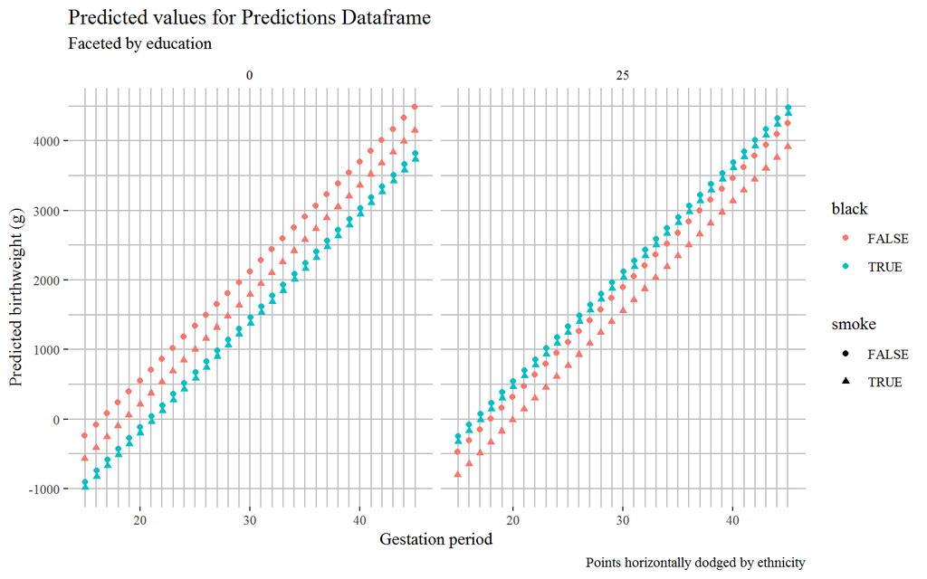

```r
educ_levels <- c('No education' = 0, '25 years of education' = 25)
ggplot(data = new.data.df[new.data.df$educ == 0 | new.data.df$educ == 25,]) +
  geom_point(mapping = aes(x = gestate, y = grams_fit,colour = black,group = black,shape = smoke),position = position_dodge(width = 0.1)) +
  facet_wrap(~ educ,labeller = as_labeller(educ_levels)) +
  labs(title = "Predicted values for Predictions Dataframe",
       subtitle = "Faceted by education",
       x = "Gestation period",
       y = "Predicted birthweight (g)",
       caption = "Points horizontally dodged by ethnicity") +
  theme_tufte() +
  theme(panel.grid.minor  = element_line(colour = 'grey',size = 0.5),
        panel.grid.major  = element_line(colour = 'grey',size = 0.5)) +
    scale_x_continuous(minor_breaks = seq(from = 15, to = 45,by = 1))
```

This graph actually illustrates most of the key points we wish to make about our model. Our model, for better or worses, maps birthweight linearly to gestation period (shown by the straight line relationship). This leads to illogical predictions at early gestation periods. Education has a beneficial moderating influence on African American ethnicity and weight (as shown by the colours swapping vertical positions between the first and second graph). African American ethnicity has a negative effect on ethnicity, as shown by the positions of the colours on the first faceted graph.

Finally, the negative effects of smoking (as illustrated by the vertical distance between red circles and triangles) and ethnicity (illustrated by the vertical distance between red and blue points) do not interact purely additively (such that a mother in both these categories would be expected to have a baby a full kilogram less than a non-smoking non-African mother). The positive interaction term African American:Smoking shows that this situation results in a less severe scenario (shown by the lower vertical distance of blue triangles and circles than red triangles and circle).

## Context specific questions

Most of the suggested questions asked in the assignment have already been answered in the modelling process. However, we will provide a quick recap here;

- Is there a difference in the average weight of children born to black and non-black mothers?

```r
t.test((births.df$grams[births.df$black == T]),
       (births.df$grams[births.df$black == F]))
```

```
##
##  Welch Two Sample t-test
##
## data:  (births.df$grams[births.df$black == T]) and (births.df$grams[births.df$black == F])
## t = -9.0355, df = 1036.1, p-value < 2.2e-16
## alternative hypothesis: true difference in means is not equal to 0
## 95 percent confidence interval:
##  -402.4795 -258.8556
## sample estimates:
## mean of x mean of y
##  3085.193  3415.861
```

- Does smoking during pregnancy affect a baby’s birth weight?

```r
t.test((births.df$grams[births.df$smoke == T]),
       (births.df$grams[births.df$smoke == F]))
```

```
##
##  Welch Two Sample t-test
##
## data:  (births.df$grams[births.df$smoke == T]) and (births.df$grams[births.df$smoke == F])
## t = -7.209, df = 400.02, p-value = 2.834e-12
## alternative hypothesis: true difference in means is not equal to 0
## 95 percent confidence interval:
##  -429.7411 -245.5800
## sample estimates:
## mean of x mean of y
##  2963.338  3300.999
```

As above, there is a practical and significant difference in birth weights.

- *Is it sensible to use this model to describe the rate at which a baby puts on weight over a pregnancy?*

Probably not. As we have shown, the model can not backwards extrapolate below the range of the observed data accurately. It is unlikely the foetal weight varies in the linear way described by the model - this is an appropriate approximation, given the range of the observed data, but inappropriate for modelling the whole pregancy period. We could perhaps infer a rate of change in foetal weight from the relationship of gestation period and birthweights, but this would probably not accurately reflect the actual process of foetal development that occurs - the data concerns livebirths, not fetuses.

- *Are there any extremely premature babies (the typical gestational period for humans is 40 weeks) who influence the fit of this model, and should they have this influence?*

As we established during the diagnostics stage of the modelling process, no data points are even close to a large cooks distance. Some of the points have relatively high leverage, but the model seems to fit them well. Furthermore, part of the intention of the model is modelling the birthweight of premature babies. It is directly observable that there is a wide spread of birthweights at the normal gestation period, likely due to the influence of unmeasured factors (e.g. maternal weight).

- *Are the effects of any variable different for different levels of another variable e.g. does the longer a mother experiences in education have the same relationship with birth weight for black and non-black mothers?*

Our model includes two interactions; smoking and ethnicity, and education and ethnicity. These terms have been fully explained in previous sections.

# Vasoconstriction Data

We import and recoded the response variable.

```r
vaso.df <- read.table("finney2.txt",header = T)
sum(is.na(vaso.df))
```

```
## [1] 0
```

```r
vaso.df$Response <- as.logical(vaso.df$Response) #recoding to aid graphing + analysis
```

## Scatterplot

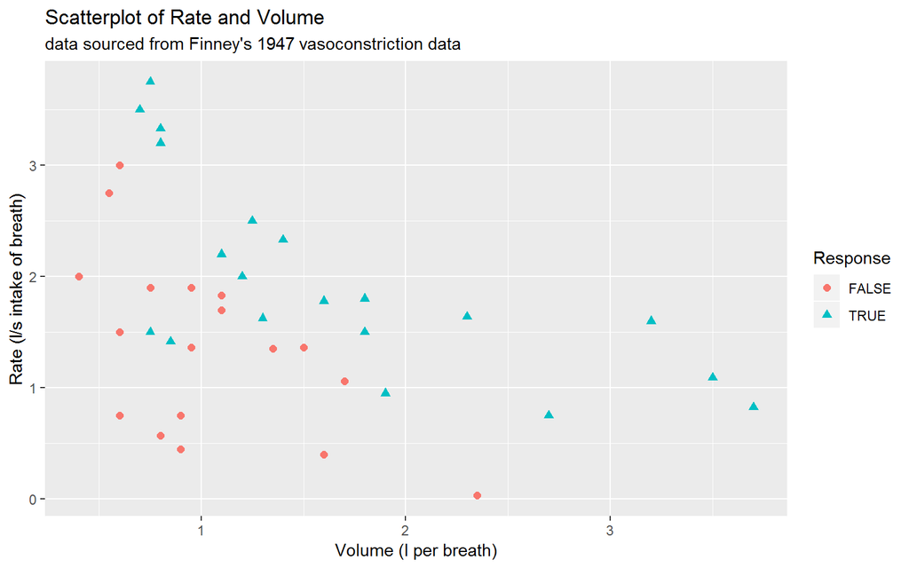

```r
ggplot(data = vaso.df) +
  geom_point(mapping = aes(y = Rate, x = Volume,shape = Response,color = Response),size = 2) +
  labs(title = "Scatterplot of Rate and Volume",
       y = "Rate (l/s intake of breath)",
       x = "Volume (l per breath)",
       subtitle = "data sourced from Finney's 1947 vasoconstriction data")
```

## Observations

There is a lack of observations in the top-right quandrant of the plot because we expect that high volumes (or deep) breaths will also be slower - the initial inward rush of air might be quite fast, but it is likely this will slow down as the lungs fill up and the diaphragm has to work to force air into the lungs. In fact, this relationship is observed directly in the data (the inverse relationship between rate and volume).

## Binomial regression models (volume, rate):

Please select the tabs below to see the models for each link function.

```r
logit_vaso.mod <- glm(data = vaso.df,Response ~ Rate + Volume,family = binomial(link = 'logit'))
probit_vaso.mod <- glm(data = vaso.df,Response ~ Rate + Volume,family = binomial(link = 'probit'))
loglog_vaso.mod <- glm(data = vaso.df,Response ~ Rate + Volume,family = binomial(link = 'cloglog'))
```

### Logit Link

```r
summary(logit_vaso.mod)
```

```
##
## Call:
## glm(formula = Response ~ Rate + Volume, family = binomial(link = "logit"),
##     data = vaso.df)
##
## Deviance Residuals:
##      Min        1Q    Median        3Q       Max
## -1.50657  -0.73464   0.03997   0.48854   2.32935
##
## Coefficients:
##             Estimate Std. Error z value Pr(>|z|)
## (Intercept)  -9.5296     3.2332  -2.947  0.00320 **
## Rate          2.6491     0.9142   2.898  0.00376 **
## Volume        3.8822     1.4286   2.717  0.00658 **
## ---
## Signif. codes:  0 '***' 0.001 '**' 0.01 '*' 0.05 '.' 0.1 ' ' 1
##
## (Dispersion parameter for binomial family taken to be 1)
##
##     Null deviance: 54.040  on 38  degrees of freedom
## Residual deviance: 29.772  on 36  degrees of freedom
## AIC: 35.772
##
## Number of Fisher Scoring iterations: 6
```

### Probit Link

```r
summary(probit_vaso.mod)
```

```
##
## Call:
## glm(formula = Response ~ Rate + Volume, family = binomial(link = "probit"),
##     data = vaso.df)
##
## Deviance Residuals:
##      Min        1Q    Median        3Q       Max
## -1.53775  -0.81144   0.00892   0.48665   2.23618
##
## Coefficients:
##             Estimate Std. Error z value Pr(>|z|)
## (Intercept)  -5.1945     1.5939  -3.259  0.00112 **
## Rate          1.4764     0.4619   3.196  0.00139 **
## Volume        2.1181     0.7177   2.951  0.00316 **
## ---
## Signif. codes:  0 '***' 0.001 '**' 0.01 '*' 0.05 '.' 0.1 ' ' 1
##
## (Dispersion parameter for binomial family taken to be 1)
##
##     Null deviance: 54.040  on 38  degrees of freedom
## Residual deviance: 30.013  on 36  degrees of freedom
## AIC: 36.013
##
## Number of Fisher Scoring iterations: 7
```

### Log-Log Link

```r
summary(loglog_vaso.mod)
```

```
##
## Call:
## glm(formula = Response ~ Rate + Volume, family = binomial(link = "cloglog"),
##     data = vaso.df)
##
## Deviance Residuals:
##     Min       1Q   Median       3Q      Max
## -1.4360  -0.6815   0.0000   0.2818   2.3251
##
## Coefficients:
##             Estimate Std. Error z value Pr(>|z|)
## (Intercept)   -8.335      2.582  -3.228  0.00125 **
## Rate           2.129      0.655   3.251  0.00115 **
## Volume         3.297      1.137   2.900  0.00373 **
## ---
## Signif. codes:  0 '***' 0.001 '**' 0.01 '*' 0.05 '.' 0.1 ' ' 1
##
## (Dispersion parameter for binomial family taken to be 1)
##
##     Null deviance: 54.040  on 38  degrees of freedom
## Residual deviance: 27.427  on 36  degrees of freedom
## AIC: 33.427
##
## Number of Fisher Scoring iterations: 10
```

## Best Model - significance

All predictors are significant to a 99% level of confidence for all three models. We can compare the residual deviances and see that the third model - the complimentary log-log link model, mimises the error. However, we do not know if this is due to chance or due to a significant difference between the explanatory power in the models. This is also reflected by the fact the complimentary log-log model minmises the AIC criteria.

```r
anova(logit_vaso.mod,probit_vaso.mod,loglog_vaso.mod)
```

```
## Analysis of Deviance Table
##
## Model 1: Response ~ Rate + Volume
## Model 2: Response ~ Rate + Volume
## Model 3: Response ~ Rate + Volume
##   Resid. Df Resid. Dev Df Deviance
## 1        36     29.772
## 2        36     30.013  0 -0.24094
## 3        36     27.427  0  2.58599
```

## Binomial regression models - logged predictors

```r
logged_logit_vaso.mod <- glm(data = vaso.df,Response ~ log(Rate) + log(Volume),family = binomial(link = 'logit'))
logged_probit_vaso.mod <- glm(data = vaso.df,Response ~ log(Rate) + log(Volume),family = binomial(link = 'probit'))
logged_loglog_vaso.mod <- glm(data = vaso.df,Response ~ log(Rate) + log(Volume),family = binomial(link = 'cloglog'))
```

### Logit Link

```r
summary(logged_logit_vaso.mod)
```

```
##
## Call:
## glm(formula = Response ~ log(Rate) + log(Volume), family = binomial(link = "logit"),
##     data = vaso.df)
##
## Deviance Residuals:
##     Min       1Q   Median       3Q      Max
## -1.4527  -0.6110   0.1001   0.6181   2.2775
##
## Coefficients:
##             Estimate Std. Error z value Pr(>|z|)
## (Intercept)   -2.875      1.321  -2.177  0.02946 *
## log(Rate)      4.562      1.838   2.482  0.01306 *
## log(Volume)    5.179      1.865   2.778  0.00547 **
## ---
## Signif. codes:  0 '***' 0.001 '**' 0.01 '*' 0.05 '.' 0.1 ' ' 1
##
## (Dispersion parameter for binomial family taken to be 1)
##
##     Null deviance: 54.040  on 38  degrees of freedom
## Residual deviance: 29.227  on 36  degrees of freedom
## AIC: 35.227
##
## Number of Fisher Scoring iterations: 6
```

### Probit Link

```r
summary(logged_probit_vaso.mod)
```

```
##
## Call:
## glm(formula = Response ~ log(Rate) + log(Volume), family = binomial(link = "probit"),
##     data = vaso.df)
##
## Deviance Residuals:
##      Min        1Q    Median        3Q       Max
## -1.48070  -0.69236   0.05152   0.61988   2.16851
##
## Coefficients:
##             Estimate Std. Error z value Pr(>|z|)
## (Intercept)  -1.5044     0.6844  -2.198  0.02793 *
## log(Rate)     2.5123     0.9524   2.638  0.00834 **
## log(Volume)   2.8620     0.9374   3.053  0.00226 **
## ---
## Signif. codes:  0 '***' 0.001 '**' 0.01 '*' 0.05 '.' 0.1 ' ' 1
##
## (Dispersion parameter for binomial family taken to be 1)
##
##     Null deviance: 54.040  on 38  degrees of freedom
## Residual deviance: 29.287  on 36  degrees of freedom
## AIC: 35.287
##
## Number of Fisher Scoring iterations: 8
```

### Log-Log Link

```r
summary(logged_loglog_vaso.mod)
```

```
##
## Call:
## glm(formula = Response ~ log(Rate) + log(Volume), family = binomial(link = "cloglog"),
##     data = vaso.df)
##
## Deviance Residuals:
##     Min       1Q   Median       3Q      Max
## -1.4180  -0.5697   0.0000   0.4072   2.3012
##
## Coefficients:
##             Estimate Std. Error z value Pr(>|z|)
## (Intercept)   -2.974      1.093  -2.720  0.00653 **
## log(Rate)      3.970      1.382   2.872  0.00408 **
## log(Volume)    4.336      1.559   2.782  0.00541 **
## ---
## Signif. codes:  0 '***' 0.001 '**' 0.01 '*' 0.05 '.' 0.1 ' ' 1
##
## (Dispersion parameter for binomial family taken to be 1)
##
##     Null deviance: 54.040  on 38  degrees of freedom
## Residual deviance: 26.622  on 36  degrees of freedom
## AIC: 32.622
##
## Number of Fisher Scoring iterations: 10
```

## Best model - comparison with untransformed predictors

```r
anova(logged_logit_vaso.mod,logged_probit_vaso.mod,logged_loglog_vaso.mod)
```

```
## Analysis of Deviance Table
##
## Model 1: Response ~ log(Rate) + log(Volume)
## Model 2: Response ~ log(Rate) + log(Volume)
## Model 3: Response ~ log(Rate) + log(Volume)
##   Resid. Df Resid. Dev Df Deviance
## 1        36     29.227
## 2        36     29.287  0 -0.05969
## 3        36     26.622  0  2.66499
```

## Predict vasocontriction under both logit models

```r
newvaso.df = as.data.frame(cbind(c(1,3.1,0.4),c(0.9,1.2,2.6)))
colnames(newvaso.df) <- c("Volume","Rate")
```

### Breath of 1 litre at 0.9 L/s

Below are the probabilities of vasoconstriction for an individual taking a 1 L breath at a rate of 0.9 L/s.

```r
predict(logged_logit_vaso.mod,newdata = newvaso.df[1,],type =  'response')
```

```
##          1
## 0.03369786
```

```r
predict(logit_vaso.mod,newdata = newvaso.df[1,],type =  'response')
```

```
##          1
## 0.03685443
```

### Breath 3.1 litres at 1.2 L/s

Below are the probabilities of vasoconstriction for an individual taking a 3.1 L breath at a rate of 1.2 L/s.

```r
predict(logged_logit_vaso.mod,newdata = newvaso.df[2,],type =  'response')
```

```
##         2
## 0.9784621
```

```r
predict(logit_vaso.mod,newdata = newvaso.df[2,],type =  'response')
```

```
##         2
## 0.9966117
```

### Breath 0.4 litres at 2.6 L/s

Below are the probabilities of vasoconstriction for an individual taking a 0.4 L breath at a rate of 2.6 L/s.

```r
predict(logged_logit_vaso.mod,newdata = newvaso.df[3,],type =  'response')
```

```
##          3
## 0.03688189
```

```r
predict(logit_vaso.mod,newdata = newvaso.df[3,],type =  'response')
```

```
##         3
## 0.2518032
```

### p-values for goodness-of-fit statistics for logit models

We test the two logit models by comparing them to a saturated model, with zero deviance and zero degrees of freedom. The p-value for the goodness of fit tests are indicated below.

```r
1 - pchisq(deviance(logit_vaso.mod),df.residual(logit_vaso.mod))
```

```
## [1] 0.7584313
```

```r
1 - pchisq(deviance(logged_logit_vaso.mod),df.residual(logged_logit_vaso.mod))
```

```
## [1] 0.7807045
```

Both models are not significantly different from the saturated model and hence have a good goodness-of-fit.

## Volmes and Rates combinations

To begin, we will need the coefficients of both models as vector. We also need to work out what a probability of 0.1 is once it has been transformed by the link function. The backtransformed probability is;

$$log(\frac{p}{1-p})$$

```r
log(0.1/(1-0.1)) -> target_logit
```

The coefficients are;

```r
coef_logit_vaso_mod.vec <- coef(logit_vaso.mod)
coef_logged_logit_vaso_mod.vec <- coef(logged_logit_vaso.mod)
```

We can shift the intercept to the other side of this equation. Hence we find we are solving for two unknowns. We can get around this by creating reasonable vectors ($R_i,V_i$) for a range of values for one of the unknowns;

```r
sample_breath_volumes <- seq(from = 0, to = 4, by = 0.001)
sample_breath_rates <- seq(from  = 0, to = 4, by = 0.001)
```

Then we solve for estimated combinations of volume and rate, for the logit model;

To find a rate for a given volume we use;

$$\frac{log(\frac{p}{1-p}) - \beta_0 \, / \,\beta_1V_i}{\beta_2} = R_i$$
To find a volume for a given rate we use;

$$\frac{log(\frac{p}{1-p}) - \beta_0 \, / \,\beta_2R_i}{\beta_3} = V_i$$

This is implemented programmatically below;

```r
#system we wish to solve
#coef_logit_vaso_mod.vec[1] + coef_logit_vaso_mod.vec[2]*sample_breath_rates + coef_logit_vaso_mod.vec[3]*Unknown.mat = target_logit

pointOne_volumes <- NULL; pointOne_rates <- NULL

i = 1
for (i in 1:length(sample_breath_rates)) {
pointOne_volumes[i] = ((target_logit - coef_logit_vaso_mod.vec[1])/(coef_logit_vaso_mod.vec[2]*sample_breath_volumes[i])/coef_logit_vaso_mod.vec[3])
}

pointOne_logModel_VOLUME.df <- data.frame(cbind(pointOne_volumes,sample_breath_rates))
colnames(pointOne_logModel_VOLUME.df) <- c("Volume","Rate")

i = 1
for (i in 1:length(sample_breath_volumes)) {
pointOne_rates[i] = ((target_logit - coef_logit_vaso_mod.vec[1])/(coef_logit_vaso_mod.vec[3]*sample_breath_rates[i])/coef_logit_vaso_mod.vec[2])
}
rm(i)

pointOne_logModel_RATE.df <- data.frame(cbind(pointOne_rates,sample_breath_volumes))
colnames(pointOne_logModel_RATE.df) <- c("Rate","Volume")
```

We can then use these dataframes for prediction. We then sift through these predictions to find the closest two combinations of points that lead to a 0.1 probability of vasoconstriction;

```r
VOLUME_combo_predictions.vec <- predict(logit_vaso.mod,pointOne_logModel_VOLUME.df,type = 'response')
RATE_combo_predictions.vec <- predict(logit_vaso.mod,pointOne_logModel_RATE.df,type = 'response')

rate_combo_logit <- Closest(RATE_combo_predictions.vec,0.1);volume_combo_logit <- Closest(VOLUME_combo_predictions.vec,0.1)

logitVOULMEpoint <- (pointOne_logModel_VOLUME.df[as.numeric(names(volume_combo_logit)),])
logitRATEpoint <- (pointOne_logModel_RATE.df[as.numeric(names(rate_combo_logit)),])
```

We end up with two dataframes, suggesting a rate for each sample volume and a volume for each sample rate. We find two combination of values that predict a 0.1 probability of vasoconstriction. In practice this is probably a line across the response surface, but for now I am unsure (and have run out of time) on how to solve this.

Now we solve for estimated combinations of volume and rate, for the logged predictors logit model. This is a similar progress, but the equations actually simplify neatly.

To find a rate for a given volume we use;

$$\frac{log(\frac{p}{p-0.1}) - log(\beta_0) \, / \,log(\beta_1V_i)}{log(\beta_2)} = log(R_i)$$

This simplifies into;

$$\frac{\frac{p}{p-0.1} - \beta_0 \, / \,\beta_1V_i}{\beta_2} = R_i$$

To find a volume for a given rate we use;

$$\frac{log(\frac{p}{1-p}) - log(\beta_0) \, / \,log(\beta_2R_i)}{log(\beta_3)} = log(V_i)$$

This simplifies into;

$$\frac{\frac{p}{1-p} - \beta_0 \, / \,\beta_2R_i}{\beta_3} = V_i$$

Because of this simplification, the backtransformation of the probability is simpler;

```r
target_logit_2 <- (0.1/(1-0.1))
```

We log the reasonable predictors, as this is the form of the logged logit model.

```r
log_sample_breath_volumes <- log(seq(from = 0, to = 4, by = 0.001))
log_sample_breath_rates <- log(seq(from  = 0, to = 4, by = 0.001))
```

But otherwise the process follows as before (with some backtransforming inside the algorithm to account for what logging is going and what the R predict function will expect as input);

```r
#system we wish to solve
#coef_logit_vaso_mod.vec[1] + coef_logit_vaso_mod.vec[2]*sample_breath_rates + coef_logit_vaso_mod.vec[3]*Unknown.mat = target_logit

pointOne_logged_volumes <- NULL; pointOne_logged_rates <- NULL

i = 1
for (i in 1:length(log_sample_breath_rates)) {
pointOne_logged_volumes[i] = ((target_logit - coef_logged_logit_vaso_mod.vec[1])/(coef_logged_logit_vaso_mod.vec[2]*log_sample_breath_volumes[i])/coef_logged_logit_vaso_mod.vec[3])
}

pointOne_logged_logModel_VOLUME.df <- data.frame(cbind(exp(pointOne_logged_volumes),exp(log_sample_breath_rates)))
colnames(pointOne_logged_logModel_VOLUME.df) <- c("Volume","Rate")

i = 1
for (i in 1:length(log_sample_breath_volumes)) {
pointOne_logged_rates[i] = ((target_logit - coef_logged_logit_vaso_mod.vec[1])/(coef_logged_logit_vaso_mod.vec[3]*log_sample_breath_rates[i])/coef_logged_logit_vaso_mod.vec[2])
}
rm(i)

pointOne_logged_logModel_RATE.df <- data.frame(cbind(exp(pointOne_logged_rates),exp(log_sample_breath_volumes)))
colnames(pointOne_logged_logModel_RATE.df) <- c("Rate","Volume")
```

Again, we can then use these dataframes for prediction. We then sift through these predictions to find the closest two combinations of points that lead to a 0.1 probability of vasoconstriction for the logged logit model;

```r
VOLUME_combo_logged_predictions.vec <- predict(logged_logit_vaso.mod,pointOne_logged_logModel_VOLUME.df,type='response')
RATE_combo_logged_predictions.vec <- predict(logged_logit_vaso.mod,pointOne_logged_logModel_RATE.df,type = 'response')

rate_combo_logged_logit <- Closest(RATE_combo_logged_predictions.vec,0.1);volume_combo_logged_logit <- Closest(VOLUME_combo_logged_predictions.vec,0.1)

loggedlogitVOULMEpoint <- (pointOne_logged_logModel_VOLUME.df[as.numeric(names(volume_combo_logged_logit)),])
loggedlogitRATEpoint <- (pointOne_logged_logModel_RATE.df[as.numeric(names(rate_combo_logged_logit)),])
```

We now wrap these four points into a dataframe for the scatterplot;

```r
modelPointsP1.df <- rbind(loggedlogitRATEpoint,loggedlogitVOULMEpoint,logitRATEpoint,logitVOULMEpoint)
```

### Plot the points used for predictions

Finally, we can plot the points that generate a probability of 0.1, in addition to the points used in the predictions earlier, onto the original scatterplot.

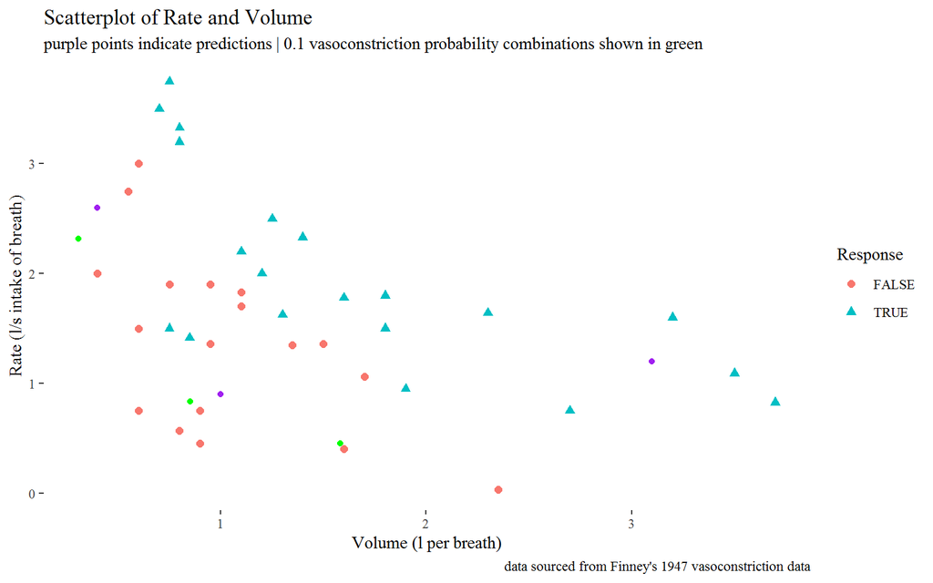

```r
ggplot(data = vaso.df) +
  geom_point(mapping = aes(y = Rate, x = Volume,shape = Response,color = Response),size = 2) +
  geom_point(data = newvaso.df,mapping = aes(y = Rate,x = Volume),color = 'purple') +
  geom_point(data = modelPointsP1.df,mapping = aes(y = Rate,x = Volume),color = 'green') +
  labs(title = "Scatterplot of Rate and Volume",
       y = "Rate (l/s intake of breath)",
       x = "Volume (l per breath)",
       caption = "data sourced from Finney's 1947 vasoconstriction data",
       subtitle = "purple points indicate predictions | 0.1 vasoconstriction probability combinations shown in green") +
  theme_tufte()
```

## References

- University of Pennsylvania Eberly College of Science.**Chi-sq test of independance**. Retrieved September 09, 2018, from https://onlinecourses.science.psu.edu/stat500/node/56/.
- University of Pennsylvania College of Health and Human Development. **AIC vs. BIC**. Retrieved September 10, 2018 from https://methodology.psu.edu/AIC-vs-BIC.
- University of Pennsylvania Eberly College of Science.**Best Subsets Regression, Adjusted R-Sq, Mallows Cp**. Retrieved September 10, 2018, from https://onlinecourses.science.psu.edu/stat501/node/330/.
- Southern Health Alliance. **Pre-term birth**. Retrieved from https://bit.ly/2MXO7vR (link has been shortened).
- Kass, Robert E; Raftery, Adrian E. (1995), **Bayes Factors**, Journal of the American Statistical Association, 90 (430): 773-795, doi:10.2307/2291091, ISSN 0162-1459.

## Additional notes

- Help from stackoverflow was gratefully provided by user20650; https://stackoverflow.com/questions/35085261/how-to-use-loess-method-in-ggallyggpairs-using-wrap-function.
- Help from stackoverflow was gratefully provided by Sven Hohenstein; https://stackoverflow.com/questions/21708764/cannot-change-text-size-in-regsubsets-plot.
- Help from stackoverflow was gratefully provided by mnel; https://stackoverflow.com/questions/17737159/controlling-the-value-true-or-false-of-dummy-variables-in-interaction-terms-wh
- Guide to solving for probability p in logistic regression was found here; http://logisticregressionanalysis.com/910-how-to-solve-the-logistic-regression-equation-for-the-probability-p/

## Packages

H. Wickham. ggplot2: Elegant Graphics for Data Analysis. Springer-Verlag New York, 2016.

Hadley Wickham, Romain François, Lionel Henry and Kirill Müller (2018). dplyr: A Grammar of Data Manipulation. R package version 0.7.6. https://CRAN.R-project.org/package=dplyr

Thomas Lumley based on Fortran code by Alan Miller (2017). leaps: Regression Subset Selection. R package version 3.0. https://CRAN.R-project.org/package=leaps

Julien Barnier (2017). rmdformats: HTML Output Formats and Templates for ‘rmarkdown’ Documents. R package version 0.3.3. https://CRAN.R-project.org/package=rmdformats

Stefan Milton Bache and Hadley Wickham (2014). magrittr: A Forward-Pipe Operator for R. R package version 1.5. https://CRAN.R-project.org/package=magrittr

Barret Schloerke, Jason Crowley, Di Cook, Francois Briatte, Moritz Marbach, Edwin Thoen, Amos Elberg and Joseph Larmarange (2018). GGally: Extension to ‘ggplot2’. R package version 1.4.0. https://CRAN.R-project.org/package=GGally

Jeffrey B. Arnold (2018). ggthemes: Extra Themes, Scales and Geoms for ‘ggplot2’. R package version 4.0.1.https://CRAN.R-project.org/package=ggthemes

Hlavac, Marek (2018). stargazer: Well-Formatted Regression and Summary Statistics Tables. R package version 5.2.1. https://CRAN.R-project.org/package=stargazer

Hao Zhu (2018). kableExtra: Construct Complex Table with ‘kable’ and Pipe Syntax. R package version 0.9.0. https://CRAN.R-project.org/package=kableExtra

Kirill Müller and Hadley Wickham (2018). tibble: Simple Data Frames. R package version 1.4.2. https://CRAN.R-project.org/package=tibble

Yuan Tang, Masaaki Horikoshi, and Wenxuan Li. “ggfortify: Unified Interface to Visualize Statistical Result of Popular R Packages.” The R Journal 8.2 (2016): 478-489.

Matthew Skiffington